# part3

me

12 joulukuuta 2019

# 3. Poolaus

## 3.1 Presence/absence -aineisto

### 3.1.1 Aineisto sisälle ja periodien keskiarvojen lasku

Luetaan havainnot ja ennusteet sisään ja lasketaan kullekin lajille periodien 1 ja 2 ennustettujen ja todellisten esiintymistodennäköisyyksien reittikohtaiset keskiarvot.

```r
getwd()
```

```
## [1] "C:/Users/Sirke Piirainen/OneDrive - University of Helsinki/github_mallinnus/model_validation"
```

```r
localDir = "."
PredictionDir = file.path(localDir, "data")

samples = 1000
thin = 1000 #muista vaihtaa tämä!!
nChains = 4
modeltype = 1 #1 on pa-aineistolle

#model 1: data until 2006; model 2: full data
#mpred1: posterior mean based on model 1; mpred2: posterior mean based on model 2

filename = file.path(PredictionDir, paste("predictions_",c("pa","abundance")[modeltype],
                                          "_chains_",as.character(nChains),"_thin_", as.character(thin),"_samples_", as.character(samples),
                                          ".Rdata",sep = ""))
load(filename) #mpred1, mpred2, Y, studyDesign
routes=levels(studyDesign$Route)
nr=length(routes)
years=levels(studyDesign$Year)
ns=dim(mpred1)[2]

#määritellään periodit
period1=(studyDesign$Year=="Year_1996" | studyDesign$Year=="Year_1997" | studyDesign$Year=="Year_1998" | studyDesign$Year=="Year_1999")
period2=(studyDesign$Year=="Year_2013" | studyDesign$Year=="Year_2014" | studyDesign$Year=="Year_2015" | studyDesign$Year=="Year_2016")

#valitaan ennusteista ja havainnoista oikeat vuodet
pm1p1=mpred1[period1,]
pm1p2=mpred1[period2,] #pm1p2 = predictions by model 1 to period 2

y1=Y[period1,]
y2=Y[period2,]

#lasketaan kuinka monta kertaa kullakin linjalla on k?yty
sd1 = studyDesign[period1,]
sd2 = studyDesign[period2,]

visits1 = rep(NA,nr)
visits2 = rep(NA,nr)
for (i in 1:nr){
  visits1[i] = sum(sd1$Route==routes[i])
  visits2[i] = sum(sd2$Route==routes[i])
}

#lasketaan kullekin linjalle (jolla on käyty kahdesti kummankin periodin aikana, yhteensä 592 kpl) keskiarvot periodeittain
#havainnot ja ennusteet erikseen, periodit 1 ja 2 erikseen
selroutes = routes[which(visits1>=2 & visits2>=2)]
nsr = length(selroutes)

Ap1=matrix(NA,nrow = nsr,ncol = ns)
Ap2=matrix(NA,nrow = nsr,ncol = ns)
Ay1=matrix(NA,nrow = nsr,ncol = ns)
Ay2=matrix(NA,nrow = nsr,ncol = ns)

for (i in 1:nsr){
  take1 = which(sd1$Route == selroutes[i] )
  take2 = which(sd2$Route == selroutes[i] )
  Ap1[i,] = colMeans(pm1p1[take1,])
  Ap2[i,] = colMeans(pm1p2[take2,])
  Ay1[i,] = colMeans(y1[take1,]) #Suomen vesilinnut vain NA:ta
  Ay2[i,] = colMeans(y2[take2,])
}
```

Kolme reittiä taitaa olla Suomessa, joten niiden kohdalla vesilintujen havainnot ovat NA:ta.

### 3.1.2 Koordinaattien lisääminen

Seuraavaksi liitetään kuhunkin reittiin koordinaatit.

```r
#lisätään kullekin linjalle koordinaatit
routeyear<-read.csv("studydesign.csv",header=T,sep=",")
xy<-read.csv("xy.csv",header=T,sep=",")

#koordinaateista puuttuu nollia
xy<-xy%>%
  mutate(x = x * 1000) %>%
  mutate(y = y * 1000)

#jotta koordinaatit saa liitettyä oikealle linjalle, tehdään taulukko, jossa reiteillä on molemmat koodaukset (alkuperäiset ja 1-2591)
Route<-unique(routeyear$Route)
routeid<-c(1:2591)
d<-data.frame(Route,routeid)

#matriisit on muutettava dataframeiksi
Ap1=as.data.frame(Ap1)
Ap1=cbind(selroutes,Ap1)
setnames(Ap1,"selroutes","Route")

Ap2=as.data.frame(Ap2)
Ap2=cbind(selroutes,Ap2)
setnames(Ap2,"selroutes","Route")

Ay1=as.data.frame(Ay1)
Ay1=cbind(selroutes,Ay1)
setnames(Ay1,"selroutes","Route")

Ay2=as.data.frame(Ay2)
Ay2=cbind(selroutes,Ay2)
setnames(Ay2,"selroutes","Route")

#lisätään havaintoihin ja ennusteisiin ensin oikeat reittikoodit (1-2591)
Ap1<-left_join(Ap1,d,by="Route")
Ap2<-left_join(Ap2,d,by="Route")
Ay1<-left_join(Ay1,d,by="Route")
Ay2<-left_join(Ay2,d,by="Route")
#...ja vihdoin myös koordinaatit
Ap1<-left_join(Ap1,xy,by=c("routeid"="route"))
Ap2<-left_join(Ap2,xy,by=c("routeid"="route"))
Ay1<-left_join(Ay1,xy,by=c("routeid"="route"))
Ay2<-left_join(Ay2,xy,by=c("routeid"="route"))
```

Ylläolevaa koodin pätkää voi vielä siloitella jos on aikaa.

Tallennan havainnot ja ennusteet, jolloin poolausta on helpompi tarkistaa GIS:llä.

```r
#tallenna tiedot
write.csv(Ay1,"pa_obs_per1.csv",row.names = F)
write.csv(Ay2,"pa_obs_per2.csv",row.names = F)
write.csv(Ap1,"pa_pred_per1.csv",row.names = F)
write.csv(Ap2,"pa_pred_per2.csv",row.names = F)
```

### 3.1.3 Poolaus

Kootaan reitit 50 km x 50 km (tai 100x100 km) ruutuihin, eli lasketaan todelliset ja ennustetut esiintymistodennäköisyydet kaikkien yhteen ruutuun sijoittuvien reittien periodien keskiarvojen keskiarvoina.

Luetaan ensin kaikki aineisto koordinaatteineen sisälle.  
Ay1 ja 2 ovat todellisia havaintoja, periodeittain. Ap1 ja 2 ovat ennusteita.

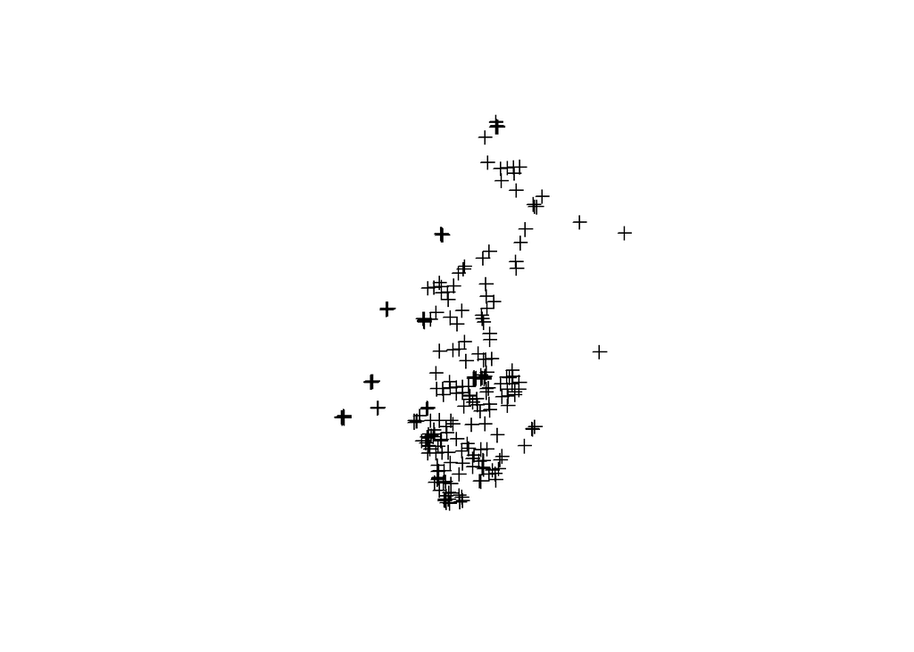

```r
#luetaan sisään reitit, havainnot ja ennusteet
coordinates(Ay1)<-c("x","y")
plot(Ay1)
```

```r
proj4string(Ay1) <-CRS("+init=EPSG:3035")

coordinates(Ay2)<-c("x","y")
proj4string(Ay2) <-CRS("+init=EPSG:3035")

coordinates(Ap1)<-c("x","y")
proj4string(Ap1) <-CRS("+init=EPSG:3035")

coordinates(Ap2)<-c("x","y")
proj4string(Ap2) <-CRS("+init=EPSG:3035")
```

Gridit olen tehnyt jo aiemmin QGis:llä.

```r
gridi<- readOGR(dsn="./gridit", layer="grid50km")
#gridi<- readOGR(dsn="./gridit", layer="grid100km")
proj4string(gridi)
```

```
## [1] "+proj=laea +lat_0=52 +lon_0=10 +x_0=4321000 +y_0=3210000 +ellps=GRS80 +units=m +no_defs"
```

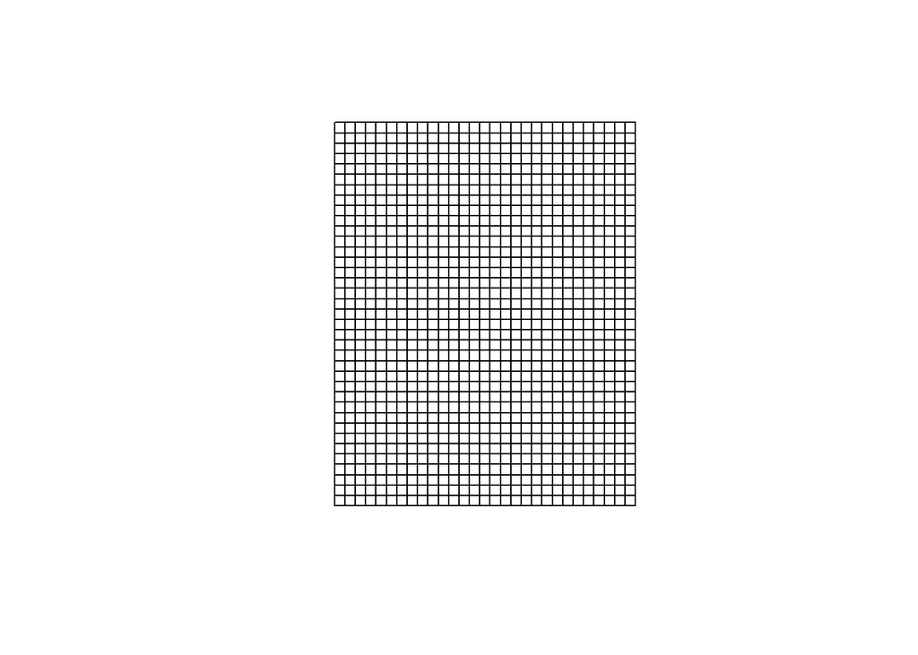

```r
plot(gridi)
```

Itse poolaus tapahtuu niin, että liitetään kuhunkin reittiin tieto, millä gridin ruudulla (id-numero) se on, jonka jälkeen ryhmitellään kaikki reitit gridiruuduittain ja lasketaan niille keskiarvot. Tallennan taas kaikki tiedot niin, että ne on helppo lukea ja tarkistaa GIS:llä.

```r
#liitetään kuhunkin reittiin tieto, millä gridin ruudulla se on
pts.poly <- point.in.poly(Ay1, gridi)
data<-as.data.frame(pts.poly)

#ryhmitelään linjat gridiruuduittain ja lasketaan keskiarvot kullekin sarakkeelle, eli lajeittain.
data%>%
  group_by(grid_id) %>%
  summarise_at(vars(-Route), list(~mean(., na.rm=T))) %>% #jos jollain lajilla on yhdellä linjalla NA:ta se ei vaikuta keskiarvon laskemiseen.
  write.csv(.,file = "pool_pa_obs_per1.csv",row.names=F)

#ja sama muille aineistoille
pts.poly <- point.in.poly(Ay2, gridi)
data<-as.data.frame(pts.poly)
data%>%
  group_by(grid_id) %>%
  summarise_at(vars(-Route), list(~mean(., na.rm=T))) %>%
  write.csv(.,file = "pool_pa_obs_per2.csv",row.names=F)

pts.poly <- point.in.poly(Ap1, gridi)
data<-as.data.frame(pts.poly)
data%>%
  group_by(grid_id) %>%
  summarise_at(vars(-Route), list(~mean(., na.rm=T))) %>%
  write.csv(.,file = "pool_pa_pred_per1.csv",row.names=F)

pts.poly <- point.in.poly(Ap2, gridi)
data<-as.data.frame(pts.poly)
data%>%
  group_by(grid_id) %>%
  summarise_at(vars(-Route), list(~mean(., na.rm=T))) %>%
  write.csv(.,file = "pool_pa_pred_per2.csv",row.names=F)
```

### 3.1.4 Poolatut ennustustarkkuudet

Lopulta lasketaan uudestaan ennustustarkkuudet poolatuilla arvoilla. Toistaiseksi vain metodilla D.

Luetaan aineisto takaisin sisään ja siivotaan sitä hieman:

```r
#luetaan aineisto takaisin sisään
paY1<-read.csv("pool_pa_obs_per1.csv",header=T,sep=",")
paY2<-read.csv("pool_pa_obs_per2.csv",header=T,sep=",")
papred1<-read.csv("pool_pa_pred_per1.csv",header=T,sep=",")
papred2<-read.csv("pool_pa_pred_per2.csv",header=T,sep=",")

#heivataan turhat sarakkeet
names(paY1)
```

```
##   [1] "grid_id"   "V1"        "V2"        "V3"        "V4"
##   [6] "V5"        "V6"        "V7"        "V8"        "V9"
##  [11] "V10"       "V11"       "V12"       "V13"       "V14"
##  [16] "V15"       "V16"       "V17"       "V18"       "V19"
##  [21] "V20"       "V21"       "V22"       "V23"       "V24"
##  [26] "V25"       "V26"       "V27"       "V28"       "V29"
##  [31] "V30"       "V31"       "V32"       "V33"       "V34"
##  [36] "V35"       "V36"       "V37"       "V38"       "V39"
##  [41] "V40"       "V41"       "V42"       "V43"       "V44"
##  [46] "V45"       "V46"       "V47"       "V48"       "V49"
##  [51] "V50"       "V51"       "V52"       "V53"       "V54"
##  [56] "V55"       "V56"       "V57"       "V58"       "V59"
##  [61] "V60"       "V61"       "V62"       "V63"       "V64"
##  [66] "V65"       "V66"       "V67"       "V68"       "V69"
##  [71] "V70"       "V71"       "V72"       "V73"       "V74"
##  [76] "V75"       "V76"       "V77"       "V78"       "V79"
##  [81] "V80"       "V81"       "V82"       "V83"       "V84"
##  [86] "V85"       "V86"       "V87"       "V88"       "V89"
##  [91] "V90"       "V91"       "V92"       "V93"       "V94"
##  [96] "V95"       "V96"       "V97"       "V98"       "V99"
## [101] "V100"      "V101"      "V102"      "V103"      "V104"
## [106] "V105"      "V106"      "V107"      "V108"      "V109"
## [111] "V110"      "V111"      "V112"      "V113"      "V114"
## [116] "V115"      "V116"      "V117"      "V118"      "V119"
## [121] "V120"      "routeid"   "left"      "top"       "right"
## [126] "bottom"    "coords.x1" "coords.x2"
```

```r
drops <- c("routeid","left","top","right","bottom","coords.x1","coords.x2")
paY1<-paY1[ , !(names(paY1) %in% drops)]
paY2<-paY2[ , !(names(paY2) %in% drops)]
papred1<-papred1[ , !(names(papred1) %in% drops)]
papred2<-papred2[ , !(names(papred2) %in% drops)]

#korjataan sarakkeiden lajinimet kunnollisiksi
a<-colnames(Y)
b<-"grid_id"
a<-c(b,a)

names(paY1)<-a
names(paY2)<-a
names(papred1)<-a
names(papred2)<-a
```

Lasketaan periodien välinen muutos havainnoille ja ennusteille ja näiden korrelaatiot. (primitiivinen koodaus, voi parannella myöhemmin..)

```r
#lasketaan erotukset periodin 1 ja 2 välilä
#pa
#obs
pacounts_gather<-gather(paY1,key="Yspecies",value="Yper1",Acrocephalus_palustris:Vanellus_vanellus)
pacounts_gather2<-gather(paY2,key="Yspecies",value="Yper2",Acrocephalus_palustris:Vanellus_vanellus)
payhd<-left_join(pacounts_gather,pacounts_gather2,by=c("grid_id"="grid_id","Yspecies"="Yspecies"))
payhd$difY<-payhd$Yper2-payhd$Yper1

#pred
papred_gather<-gather(papred1,key="Pspecies",value="Pper1",Acrocephalus_palustris:Vanellus_vanellus)
papred_gather2<-gather(papred2,key="Pspecies",value="Pper2",Acrocephalus_palustris:Vanellus_vanellus)
payhdPred<-left_join(papred_gather,papred_gather2,by=c("grid_id"="grid_id","Pspecies"="Pspecies"))
payhdPred$difPred<-payhdPred$Pper2-payhdPred$Pper1

#yhdistetään tulokset, havainnot ja ennusteet samaan dataframeen
paKor<-left_join(payhd,payhdPred,by=c("grid_id"="grid_id","Yspecies"="Pspecies"))
keep<-c("Yspecies","difPred","difY")
paKor<-paKor[,keep,drop=F]

#lasketaan korrelaatiot
paKor %>%
  group_by(Yspecies) %>%
  dplyr::summarise(pool_pa_change= cor(difPred, difY, use= "na.or.complete"))%T>%
  write.csv('pa_pool50_results.csv',row.names=F)
```

```
## # A tibble: 120 x 2
##    Yspecies                   pool_pa_change
##    <chr>                               <dbl>
##  1 Acrocephalus_palustris            0.351
##  2 Acrocephalus_schoenobaenus        0.264
##  3 Acrocephalus_scirpaceus          -0.252
##  4 Actitis_hypoleucos               -0.181
##  5 Aegithalos_caudatus              -0.0471
##  6 Alauda_arvensis                  -0.273
##  7 Anas_crecca                      -0.168
##  8 Anas_platyrhynchos               -0.00841
##  9 Anser_anser                       0.429
## 10 Anthus_pratensis                  0.0898
## # ... with 110 more rows
```

Metodi B

```r
#yhdistetään tulokset, havainnot ja ennusteet samaan dataframeen
paKor<-left_join(payhd,payhdPred,by=c("grid_id"="grid_id","Yspecies"="Pspecies"))

#lasketaan korrelaatiot
paKor_B=paKor %>%
  group_by(Yspecies) %>%
  dplyr::summarise(pool_pa_change= cor(Pper2, Yper2, use= "na.or.complete"))%T>%
  write.csv('pa_pool50_results_methodB.csv',row.names=F)
```

Metodit C ja A

```r
getwd()
```

```
## [1] "C:/Users/Sirke Piirainen/OneDrive - University of Helsinki/github_mallinnus/model_validation"
```

```r
localDir = "."
PredictionDir = file.path(localDir, "data")

samples = 1000
thin = 1000 #muista vaihtaa tämä!!
nChains = 4
modeltype = 1 #1 on pa-aineistolle

#model 1: data until 2006; model 2: full data
#mpred1: posterior mean based on model 1; mpred2: posterior mean based on model 2

filename = file.path(PredictionDir, paste("predictions_",c("pa","abundance")[modeltype],
                                          "_chains_",as.character(nChains),"_thin_", as.character(thin),"_samples_", as.character(samples),
                                          ".Rdata",sep = ""))
load(filename) #mpred1, mpred2, Y, studyDesign
routes=levels(studyDesign$Route)
nr=length(routes)
years=levels(studyDesign$Year)
ns=dim(mpred1)[2]

#määritellään periodit
period1=(studyDesign$Year=="Year_1996" | studyDesign$Year=="Year_1997" | studyDesign$Year=="Year_1998" | studyDesign$Year=="Year_1999")
period2=(studyDesign$Year=="Year_2013" | studyDesign$Year=="Year_2014" | studyDesign$Year=="Year_2015" | studyDesign$Year=="Year_2016")

#valitaan ennusteista ja havainnoista oikeat vuodet
pm2p1=mpred1[period1,]
pm2p2=mpred1[period2,] #tähän vaihdetaan m2 eli malli2, jonka sovituksessa käytetty koko aineistoa

y1=Y[period1,]
y2=Y[period2,]

#lasketaan kuinka monta kertaa kullakin linjalla on k?yty
sd1 = studyDesign[period1,]
sd2 = studyDesign[period2,]

visits1 = rep(NA,nr)
visits2 = rep(NA,nr)
for (i in 1:nr){
  visits1[i] = sum(sd1$Route==routes[i])
  visits2[i] = sum(sd2$Route==routes[i])
}

#lasketaan kullekin linjalle (jolla on käyty kahdesti kummankin periodin aikana, yhteensä 592 kpl) keskiarvot periodeittain
#havainnot ja ennusteet erikseen, periodit 1 ja 2 erikseen
selroutes = routes[which(visits1>=2 & visits2>=2)]
nsr = length(selroutes)

Ap1=matrix(NA,nrow = nsr,ncol = ns)
Ap2=matrix(NA,nrow = nsr,ncol = ns)
Ay1=matrix(NA,nrow = nsr,ncol = ns)
Ay2=matrix(NA,nrow = nsr,ncol = ns)

for (i in 1:nsr){
  take1 = which(sd1$Route == selroutes[i] )
  take2 = which(sd2$Route == selroutes[i] )
  Ap1[i,] = colMeans(pm1p1[take1,])
  Ap2[i,] = colMeans(pm1p2[take2,])
  Ay1[i,] = colMeans(y1[take1,]) #Suomen vesilinnut vain NA:ta
  Ay2[i,] = colMeans(y2[take2,])
}
```

```r
#matriisit on muutettava dataframeiksi
Ap1=as.data.frame(Ap1)
Ap1=cbind(selroutes,Ap1)
setnames(Ap1,"selroutes","Route")

Ap2=as.data.frame(Ap2)
Ap2=cbind(selroutes,Ap2)
setnames(Ap2,"selroutes","Route")

Ay1=as.data.frame(Ay1)
Ay1=cbind(selroutes,Ay1)
setnames(Ay1,"selroutes","Route")

Ay2=as.data.frame(Ay2)
Ay2=cbind(selroutes,Ay2)
setnames(Ay2,"selroutes","Route")

#lisätään havaintoihin ja ennusteisiin ensin oikeat reittikoodit (1-2591)
Ap1<-left_join(Ap1,d,by="Route")
Ap2<-left_join(Ap2,d,by="Route")
Ay1<-left_join(Ay1,d,by="Route")
Ay2<-left_join(Ay2,d,by="Route")
```

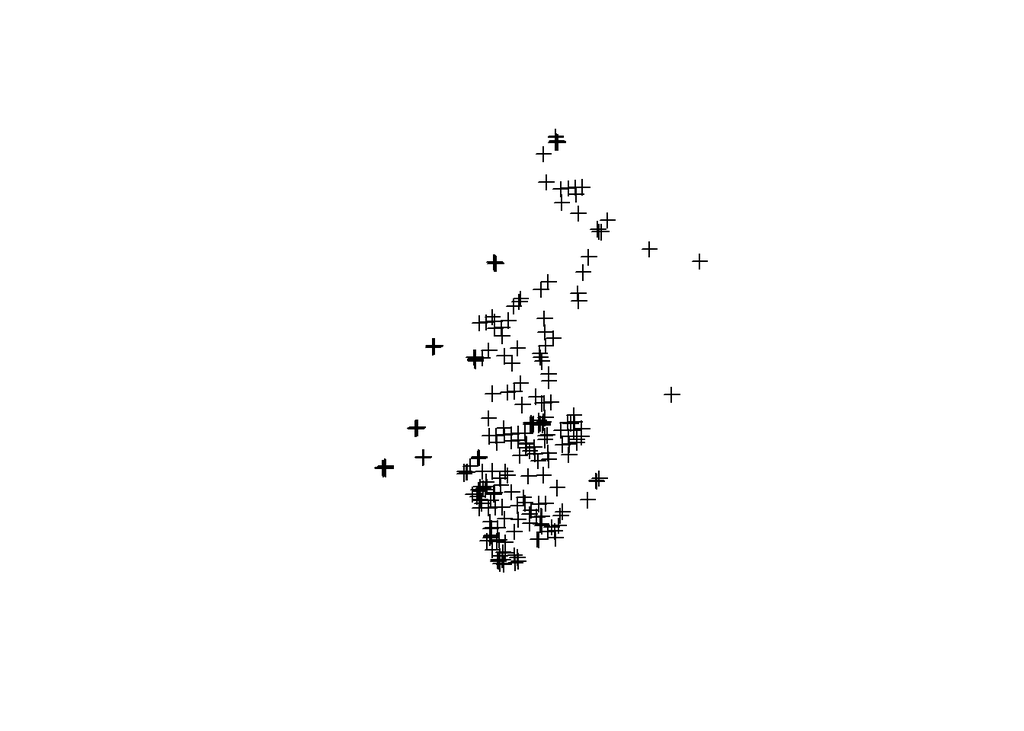

```r
#...ja vihdoin myös koordinaatit
Ap1<-left_join(Ap1,xy,by=c("routeid"="route"))
Ap2<-left_join(Ap2,xy,by=c("routeid"="route"))
Ay1<-left_join(Ay1,xy,by=c("routeid"="route"))
Ay2<-left_join(Ay2,xy,by=c("routeid"="route"))

#tallenna tiedot
write.csv(Ay1,"pa_obs_per1.csv",row.names = F)
write.csv(Ay2,"pa_obs_per2.csv",row.names = F)
write.csv(Ap1,"pa_pred_per1.csv",row.names = F)
write.csv(Ap2,"pa_pred_per2.csv",row.names = F)

#luetaan sisään reitit, havainnot ja ennusteet
coordinates(Ay1)<-c("x","y")
plot(Ay1)
```

```r
proj4string(Ay1) <-CRS("+init=EPSG:3035")

coordinates(Ay2)<-c("x","y")
proj4string(Ay2) <-CRS("+init=EPSG:3035")

coordinates(Ap1)<-c("x","y")
proj4string(Ap1) <-CRS("+init=EPSG:3035")

coordinates(Ap2)<-c("x","y")
proj4string(Ap2) <-CRS("+init=EPSG:3035")

#liitetään kuhunkin reittiin tieto, millä gridin ruudulla se on
pts.poly <- point.in.poly(Ay1, gridi)
data<-as.data.frame(pts.poly)

#ryhmitelään linjat gridiruuduittain ja lasketaan keskiarvot kullekin sarakkeelle, eli lajeittain.
data%>%
  group_by(grid_id) %>%
  summarise_at(vars(-Route), list(~mean(., na.rm=T))) %>% #jos jollain lajilla on yhdellä linjalla NA:ta se ei vaikuta keskiarvon laskemiseen.
  write.csv(.,file = "pool_pa_obs_per1.csv",row.names=F)

#ja sama muille aineistoille
pts.poly <- point.in.poly(Ay2, gridi)
data<-as.data.frame(pts.poly)
data%>%
  group_by(grid_id) %>%
  summarise_at(vars(-Route), list(~mean(., na.rm=T))) %>%
  write.csv(.,file = "pool_pa_obs_per2.csv",row.names=F)

pts.poly <- point.in.poly(Ap1, gridi)
data<-as.data.frame(pts.poly)
data%>%
  group_by(grid_id) %>%
  summarise_at(vars(-Route), list(~mean(., na.rm=T))) %>%
  write.csv(.,file = "pool_pa_pred_per1.csv",row.names=F)

pts.poly <- point.in.poly(Ap2, gridi)
data<-as.data.frame(pts.poly)
data%>%
  group_by(grid_id) %>%
  summarise_at(vars(-Route), list(~mean(., na.rm=T))) %>%
  write.csv(.,file = "pool_pa_pred_per2.csv",row.names=F)

#heivataan turhat sarakkeet
names(paY1)
```

```
##   [1] "grid_id"                       "Acrocephalus_palustris"
##   [3] "Acrocephalus_schoenobaenus"    "Acrocephalus_scirpaceus"
##   [5] "Actitis_hypoleucos"            "Aegithalos_caudatus"
##   [7] "Alauda_arvensis"               "Anas_crecca"
##   [9] "Anas_platyrhynchos"            "Anser_anser"
##  [11] "Anthus_pratensis"              "Anthus_trivialis"
##  [13] "Apus_apus"                     "Ardea_cinerea"
##  [15] "Aythya_fuligula"               "Bonasa_bonasia"
##  [17] "Branta_canadensis"             "Bucephala_clangula"
##  [19] "Buteo_buteo"                   "Carduelis_cannabina"
##  [21] "Carduelis_carduelis"           "Carduelis_chloris"
##  [23] "Carduelis_flammea"             "Carduelis_spinus"
##  [25] "Carpodacus_erythrinus"         "Certhia_familiaris"
##  [27] "Coccothraustes_coccothraustes" "Columba_livia"
##  [29] "Columba_oenas"                 "Columba_palumbus"
```

[output cut: 46 more lines]

```r
drops <- c("routeid","left","top","right","bottom","coords.x1","coords.x2")
paY1<-paY1[ , !(names(paY1) %in% drops)]
paY2<-paY2[ , !(names(paY2) %in% drops)]
papred1<-papred1[ , !(names(papred1) %in% drops)]
papred2<-papred2[ , !(names(papred2) %in% drops)]

#korjataan sarakkeiden lajinimet kunnollisiksi
a<-colnames(Y)
b<-"grid_id"
a<-c(b,a)

names(paY1)<-a
names(paY2)<-a
names(papred1)<-a
names(papred2)<-a

#lasketaan erotukset periodin 1 ja 2 välilä
#pa
#obs
pacounts_gather<-gather(paY1,key="Yspecies",value="Yper1",Acrocephalus_palustris:Vanellus_vanellus)
pacounts_gather2<-gather(paY2,key="Yspecies",value="Yper2",Acrocephalus_palustris:Vanellus_vanellus)
payhd<-left_join(pacounts_gather,pacounts_gather2,by=c("grid_id"="grid_id","Yspecies"="Yspecies"))
payhd$difY<-payhd$Yper2-payhd$Yper1

#pred
papred_gather<-gather(papred1,key="Pspecies",value="Pper1",Acrocephalus_palustris:Vanellus_vanellus)
papred_gather2<-gather(papred2,key="Pspecies",value="Pper2",Acrocephalus_palustris:Vanellus_vanellus)
payhdPred<-left_join(papred_gather,papred_gather2,by=c("grid_id"="grid_id","Pspecies"="Pspecies"))
payhdPred$difPred<-payhdPred$Pper2-payhdPred$Pper1

#yhdistetään tulokset, havainnot ja ennusteet samaan dataframeen
paKor<-left_join(payhd,payhdPred,by=c("grid_id"="grid_id","Yspecies"="Pspecies"))
keep<-c("Yspecies","difPred","difY")
paKor<-paKor[,keep,drop=F]

#lasketaan korrelaatiot
paKor_C=paKor %>%
  group_by(Yspecies) %>%
  dplyr::summarise(pool_pa_change= cor(difPred, difY, use= "na.or.complete"))%T>%
  write.csv('pa_pool50_results_methodC.csv',row.names=F)

#method A

#yhdistetään tulokset, havainnot ja ennusteet samaan dataframeen
paKor<-left_join(payhd,payhdPred,by=c("grid_id"="grid_id","Yspecies"="Pspecies"))

#lasketaan korrelaatiot
paKor_A=paKor %>%
  group_by(Yspecies) %>%
  dplyr::summarise(pool_pa_change= cor(Pper2, Yper2, use= "na.or.complete"))%T>%
  write.csv('pa_pool50_results_methodA.csv',row.names=F)
```

## 3.2 Abundance -aineisto

Tehdään sama proseduuri myös abu-aineistolle.

### 3.2.1 Aineisto sisälle ja periodien keskiarvojen lasku

```r
modeltype = 2 #2 on abu-aineistolle

#model 1: data until 2006; model 2: full data
#mpred1: posterior mean based on model 1; mpred2: posterior mean based on model 2

filename = file.path(PredictionDir, paste("predictions_",c("pa","abundance")[modeltype],
                                          "_chains_",as.character(nChains),"_thin_", as.character(thin),"_samples_", as.character(samples),
                                          ".Rdata",sep = ""))
load(filename) #mpred1, mpred2, Y, studyDesign
routes=levels(studyDesign$Route)
nr=length(routes)
years=levels(studyDesign$Year)
ns=dim(mpred1)[2]

period1=(studyDesign$Year=="Year_1996" | studyDesign$Year=="Year_1997" | studyDesign$Year=="Year_1998" | studyDesign$Year=="Year_1999")
period2=(studyDesign$Year=="Year_2013" | studyDesign$Year=="Year_2014" | studyDesign$Year=="Year_2015" | studyDesign$Year=="Year_2016")

pm1p1=mpred1[period1,]
pm1p2=mpred1[period2,] #pm1p2 = predictions by model 1 to period 2

y1=Y[period1,]
y2=Y[period2,]

sd1 = studyDesign[period1,]
sd2 = studyDesign[period2,]

visits1 = rep(NA,nr)
visits2 = rep(NA,nr)
for (i in 1:nr){
  visits1[i] = sum(sd1$Route==routes[i])
  visits2[i] = sum(sd2$Route==routes[i])
}

# lasketaan kullekin linjalle (jolla on k?yty kahdesti kummankin periodin aikana) keskiarvot periodeittain
#havainnot ja ennusteet erikseen
selroutes = routes[which(visits1>=2 & visits2>=2)]
nsr = length(selroutes)

Ap1=matrix(NA,nrow = nsr,ncol = ns)
Ap2=matrix(NA,nrow = nsr,ncol = ns)
Ay1=matrix(NA,nrow = nsr,ncol = ns)
Ay2=matrix(NA,nrow = nsr,ncol = ns)

for(j in 1:ns){
  for (i in 1:nsr){
    take1 = which(sd1$Route == selroutes[i] & y1[,j]>-1)
    take2 = which(sd2$Route == selroutes[i] & y2[,j]>-1)
    Ap1[i,j] = mean(pm1p1[take1,j]) #ei laske ennusteille keskiarvoa niiltä linjoilta, jotka ovat havainnoissa NA
    Ap2[i,j] = mean(pm1p2[take2,j])
    Ay1[i,j] = mean(y1[take1,j], na.rm=T) #NA:t jätetään huomiotta keskiarvoa laskettaessa
    Ay2[i,j] = mean(y2[take2,j], na.rm=T)
  }}
```

### 3.2.2 Koordinaattien lisääminen

```r
#matriisit on muutettava dataframeiksi
Ap1=as.data.frame(Ap1)
Ap1=cbind(selroutes,Ap1)
setnames(Ap1,"selroutes","Route")

Ap2=as.data.frame(Ap2)
Ap2=cbind(selroutes,Ap2)
setnames(Ap2,"selroutes","Route")

Ay1=as.data.frame(Ay1)
Ay1=cbind(selroutes,Ay1)
setnames(Ay1,"selroutes","Route")

Ay2=as.data.frame(Ay2)
Ay2=cbind(selroutes,Ay2)
setnames(Ay2,"selroutes","Route")

#lisätään havaintoihin ja ennusteisiin ensin oikeat reittikoodit (1-2591)
Ap1<-left_join(Ap1,d,by="Route")
Ap2<-left_join(Ap2,d,by="Route")
Ay1<-left_join(Ay1,d,by="Route")
Ay2<-left_join(Ay2,d,by="Route")
#...ja koordinaatit
Ap1<-left_join(Ap1,xy,by=c("routeid"="route"))
Ap2<-left_join(Ap2,xy,by=c("routeid"="route"))
Ay1<-left_join(Ay1,xy,by=c("routeid"="route"))
Ay2<-left_join(Ay2,xy,by=c("routeid"="route"))

#save observations and predictions for pooling in GIS
write.csv(Ay1,"abu_obs_per1.csv",row.names = F)
write.csv(Ay2,"abu_obs_per2.csv",row.names = F)
write.csv(Ap1,"abu_pred_per1.csv",row.names = F)
write.csv(Ap2,"abu_pred_per2.csv",row.names = F)
```

### 3.2.3 Poolaus

```r
#luetaan sisään reitit koordinaatteineen
coordinates(Ay1)<-c("x","y")
proj4string(Ay1) <-CRS("+init=EPSG:3035")

coordinates(Ay2)<-c("x","y")
proj4string(Ay2) <-CRS("+init=EPSG:3035")

coordinates(Ap1)<-c("x","y")
proj4string(Ap1) <-CRS("+init=EPSG:3035")

coordinates(Ap2)<-c("x","y")
proj4string(Ap2) <-CRS("+init=EPSG:3035")

#join data based on polygons
pts.poly <- point.in.poly(Ay1, gridi)
data<-as.data.frame(pts.poly)
data%>%
  group_by(grid_id) %>%
  summarise_at(vars(-Route), list(~mean(., na.rm=T))) %>% #NA:t eivät vaikuta laskuihin
  write.csv(.,file = "pool_abu_obs_per1.csv",row.names=F,na="")

pts.poly <- point.in.poly(Ay2, gridi)
data<-as.data.frame(pts.poly)
data%>%
  group_by(grid_id) %>%
  summarise_at(vars(-Route), list(~mean(., na.rm=T))) %>%
  write.csv(.,file = "pool_abu_obs_per2.csv",row.names=F,na="")

pts.poly <- point.in.poly(Ap1, gridi)
data<-as.data.frame(pts.poly)
data%>%
  group_by(grid_id) %>%
  summarise_at(vars(-Route), list(~mean(., na.rm=T))) %>%
  write.csv(.,file = "pool_abu_pred_per1.csv",row.names=F,na="")

pts.poly <- point.in.poly(Ap2, gridi)
data<-as.data.frame(pts.poly)
data%>%
  group_by(grid_id) %>%
  summarise_at(vars(-Route), list(~mean(., na.rm=T))) %>%
  write.csv(.,file = "pool_abu_pred_per2.csv",row.names=F,na="")
```

### 3.2.4 Poolatut ennustustarkkuudet

Aineiston siivous:

(Huom! Koodissa olioiden nimissä on hämäävästi ‘pa’ mutta nämä ovat silti abu-aineistoa.)

```r
paY1<-read.csv("pool_abu_obs_per1.csv",header=T,sep=",")
paY2<-read.csv("pool_abu_obs_per2.csv",header=T,sep=",")
papred1<-read.csv("pool_abu_pred_per1.csv",header=T,sep=",")
papred2<-read.csv("pool_abu_pred_per2.csv",header=T,sep=",")

#heivataan turhat sarakkeet
drops <- c("routeid","left","top","right","bottom","coords.x1","coords.x2")
paY1<-paY1[ , !(names(paY1) %in% drops)]
paY2<-paY2[ , !(names(paY2) %in% drops)]
papred1<-papred1[ , !(names(papred1) %in% drops)]
papred2<-papred2[ , !(names(papred2) %in% drops)]

#korjataan sarakkeiden lajinimet kunnollisiksi
a<-colnames(Y)
b<-"grid_id"
a<-c(b,a)

names(paY1)<-a
names(paY2)<-a
names(papred1)<-a
names(papred2)<-a
```

Muutokset periodien välillä ja korrelaatiot:

```r
#seuraavaksi lasketaan erotukset periodin 1 ja 2 välilä
#abu
#obs
pacounts_gather<-gather(paY1,key="Yspecies",value="Yper1",Acrocephalus_palustris:Vanellus_vanellus)
pacounts_gather2<-gather(paY2,key="Yspecies",value="Yper2",Acrocephalus_palustris:Vanellus_vanellus)
payhd<-left_join(pacounts_gather,pacounts_gather2,by=c("grid_id"="grid_id","Yspecies"="Yspecies"))
payhd$difY<-payhd$Yper2-payhd$Yper1

#pred
papred_gather<-gather(papred1,key="Pspecies",value="Pper1",Acrocephalus_palustris:Vanellus_vanellus)
papred_gather2<-gather(papred2,key="Pspecies",value="Pper2",Acrocephalus_palustris:Vanellus_vanellus)
payhdPred<-left_join(papred_gather,papred_gather2,by=c("grid_id"="grid_id","Pspecies"="Pspecies"))
payhdPred$difPred<-payhdPred$Pper2-payhdPred$Pper1

#pa
abuKor<-left_join(payhd,payhdPred,by=c("grid_id"="grid_id","Yspecies"="Pspecies"))
keep<-c("Yspecies","difPred","difY")
abuKor<-abuKor[,keep,drop=F]

abuKor %>%
  group_by(Yspecies) %>%
  dplyr::summarise(pool_abu_change= cor(difPred, difY, use= "na.or.complete"))%T>%
  write.csv('abu_pool50_results.csv',row.names=F)
```

```
## # A tibble: 120 x 2
##    Yspecies                   pool_abu_change
##    <chr>                                <dbl>
##  1 Acrocephalus_palustris            -0.219
##  2 Acrocephalus_schoenobaenus        -0.0600
##  3 Acrocephalus_scirpaceus           -0.00968
##  4 Actitis_hypoleucos                 0.0798
##  5 Aegithalos_caudatus                0.646
##  6 Alauda_arvensis                    0.439
##  7 Anas_crecca                        0.145
##  8 Anas_platyrhynchos                 0.232
##  9 Anser_anser                        0.103
## 10 Anthus_pratensis                   0.305
## # ... with 110 more rows
```

Kuinka moneen havaintopariin poolatut ennustustarkkuudet perustuvat? vieläkö mukana on lajeja, joista vain muutama havainto?

```r
observations=abuKor %>%
  group_by(Yspecies) %>%
  dplyr::summarise(Ngrid= length(which(!is.na(difPred))))

observations
```

```
## # A tibble: 120 x 2
##    Yspecies                   Ngrid
##    <chr>                      <int>
##  1 Acrocephalus_palustris        17
##  2 Acrocephalus_schoenobaenus    14
##  3 Acrocephalus_scirpaceus       30
##  4 Actitis_hypoleucos            37
##  5 Aegithalos_caudatus           14
##  6 Alauda_arvensis               47
##  7 Anas_crecca                   17
##  8 Anas_platyrhynchos            58
##  9 Anser_anser                   21
## 10 Anthus_pratensis              45
## # ... with 110 more rows
```

Vaikea päätellä, mitkä korrelaatioista on luotettavasti laskettu. **Pohjansirkun poolattu korrelaatio perustuu edelleen vain kolmeen havaintopariin. Sen sijaan pyyn korrelaatio onkin nyt laskettu seitsemästä havaintoparista.** Huomion arvoista on myös se, että esimerkiksi sinirinnan havaintoparit ovat poolatussa aineistossa vain kahdeksan kun taas alkuperäinen korrelaatio on laskettu 34:stä havaintoparista. Poolaaminen voi siis auttaa joidenkin niiden lajien kohdalla, joille on vaikea löytää reittejä, joilla olisi käyty sekä periodi 1:llä että 2:lla. Mutta jos tarkastellaan vain sitä, kuinka harvasta gridiruudusta poolattu korrelaatio on laskettu, jää huomioimatta, että yhden ruudun “takana” voi olla useampia reittejä. Jos rajaksi asettaa saman 10 voi aineistosta pudota lajeja, joista oli useita havaintoja.

Metodi B

```r
abuKor<-left_join(payhd,payhdPred,by=c("grid_id"="grid_id","Yspecies"="Pspecies"))

abuKor_B=abuKor %>%
  group_by(Yspecies) %>%
  dplyr::summarise(pool_abu_change= cor(Pper2, Yper2, use= "na.or.complete"))%T>%
  write.csv('abu_pool50_results_methodB.csv',row.names=F)
```

Metodit A ja C

```r
modeltype = 2 #2 on abu-aineistolle

#model 1: data until 2006; model 2: full data
#mpred1: posterior mean based on model 1; mpred2: posterior mean based on model 2

filename = file.path(PredictionDir, paste("predictions_",c("pa","abundance")[modeltype],
                                          "_chains_",as.character(nChains),"_thin_", as.character(thin),"_samples_", as.character(samples),
                                          ".Rdata",sep = ""))
load(filename) #mpred1, mpred2, Y, studyDesign
routes=levels(studyDesign$Route)
nr=length(routes)
years=levels(studyDesign$Year)
ns=dim(mpred1)[2]

period1=(studyDesign$Year=="Year_1996" | studyDesign$Year=="Year_1997" | studyDesign$Year=="Year_1998" | studyDesign$Year=="Year_1999")
period2=(studyDesign$Year=="Year_2013" | studyDesign$Year=="Year_2014" | studyDesign$Year=="Year_2015" | studyDesign$Year=="Year_2016")

pm2p1=mpred1[period1,]
pm2p2=mpred1[period2,] #m2 eli käytetty koko aineistoa

y1=Y[period1,]
y2=Y[period2,]

sd1 = studyDesign[period1,]
sd2 = studyDesign[period2,]

visits1 = rep(NA,nr)
visits2 = rep(NA,nr)
for (i in 1:nr){
  visits1[i] = sum(sd1$Route==routes[i])
  visits2[i] = sum(sd2$Route==routes[i])
}

# lasketaan kullekin linjalle (jolla on k?yty kahdesti kummankin periodin aikana) keskiarvot periodeittain
#havainnot ja ennusteet erikseen
selroutes = routes[which(visits1>=2 & visits2>=2)]
nsr = length(selroutes)

Ap1=matrix(NA,nrow = nsr,ncol = ns)
Ap2=matrix(NA,nrow = nsr,ncol = ns)
Ay1=matrix(NA,nrow = nsr,ncol = ns)
Ay2=matrix(NA,nrow = nsr,ncol = ns)

for(j in 1:ns){
  for (i in 1:nsr){
    take1 = which(sd1$Route == selroutes[i] & y1[,j]>-1)
    take2 = which(sd2$Route == selroutes[i] & y2[,j]>-1)
    Ap1[i,j] = mean(pm1p1[take1,j]) #ei laske ennusteille keskiarvoa niiltä linjoilta, jotka ovat havainnoissa NA
    Ap2[i,j] = mean(pm1p2[take2,j])
    Ay1[i,j] = mean(y1[take1,j], na.rm=T) #NA:t jätetään huomiotta keskiarvoa laskettaessa
    Ay2[i,j] = mean(y2[take2,j], na.rm=T)
  }}
```

```r
#matriisit on muutettava dataframeiksi
Ap1=as.data.frame(Ap1)
Ap1=cbind(selroutes,Ap1)
setnames(Ap1,"selroutes","Route")

Ap2=as.data.frame(Ap2)
Ap2=cbind(selroutes,Ap2)
setnames(Ap2,"selroutes","Route")

Ay1=as.data.frame(Ay1)
Ay1=cbind(selroutes,Ay1)
setnames(Ay1,"selroutes","Route")

Ay2=as.data.frame(Ay2)
Ay2=cbind(selroutes,Ay2)
setnames(Ay2,"selroutes","Route")

#lisätään havaintoihin ja ennusteisiin ensin oikeat reittikoodit (1-2591)
Ap1<-left_join(Ap1,d,by="Route")
Ap2<-left_join(Ap2,d,by="Route")
Ay1<-left_join(Ay1,d,by="Route")
Ay2<-left_join(Ay2,d,by="Route")
#...ja koordinaatit
Ap1<-left_join(Ap1,xy,by=c("routeid"="route"))
Ap2<-left_join(Ap2,xy,by=c("routeid"="route"))
Ay1<-left_join(Ay1,xy,by=c("routeid"="route"))
Ay2<-left_join(Ay2,xy,by=c("routeid"="route"))

#save observations and predictions for pooling in GIS
write.csv(Ay1,"abu_obs_per1.csv",row.names = F)
write.csv(Ay2,"abu_obs_per2.csv",row.names = F)
write.csv(Ap1,"abu_pred_per1.csv",row.names = F)
write.csv(Ap2,"abu_pred_per2.csv",row.names = F)
```

```r
#luetaan sisään reitit koordinaatteineen
coordinates(Ay1)<-c("x","y")
proj4string(Ay1) <-CRS("+init=EPSG:3035")

coordinates(Ay2)<-c("x","y")
proj4string(Ay2) <-CRS("+init=EPSG:3035")

coordinates(Ap1)<-c("x","y")
proj4string(Ap1) <-CRS("+init=EPSG:3035")

coordinates(Ap2)<-c("x","y")
proj4string(Ap2) <-CRS("+init=EPSG:3035")

#join data based on polygons
pts.poly <- point.in.poly(Ay1, gridi)
data<-as.data.frame(pts.poly)
data%>%
  group_by(grid_id) %>%
  summarise_at(vars(-Route), list(~mean(., na.rm=T))) %>% #NA:t eivät vaikuta laskuihin
  write.csv(.,file = "pool_abu_obs_per1.csv",row.names=F,na="")

pts.poly <- point.in.poly(Ay2, gridi)
data<-as.data.frame(pts.poly)
data%>%
  group_by(grid_id) %>%
  summarise_at(vars(-Route), list(~mean(., na.rm=T))) %>%
  write.csv(.,file = "pool_abu_obs_per2.csv",row.names=F,na="")

pts.poly <- point.in.poly(Ap1, gridi)
data<-as.data.frame(pts.poly)
data%>%
  group_by(grid_id) %>%
  summarise_at(vars(-Route), list(~mean(., na.rm=T))) %>%
  write.csv(.,file = "pool_abu_pred_per1.csv",row.names=F,na="")

pts.poly <- point.in.poly(Ap2, gridi)
data<-as.data.frame(pts.poly)
data%>%
  group_by(grid_id) %>%
  summarise_at(vars(-Route), list(~mean(., na.rm=T))) %>%
  write.csv(.,file = "pool_abu_pred_per2.csv",row.names=F,na="")
```

```r
#heivataan turhat sarakkeet
drops <- c("routeid","left","top","right","bottom","coords.x1","coords.x2")
paY1<-paY1[ , !(names(paY1) %in% drops)]
paY2<-paY2[ , !(names(paY2) %in% drops)]
papred1<-papred1[ , !(names(papred1) %in% drops)]
papred2<-papred2[ , !(names(papred2) %in% drops)]

#korjataan sarakkeiden lajinimet kunnollisiksi
a<-colnames(Y)
b<-"grid_id"
a<-c(b,a)

names(paY1)<-a
names(paY2)<-a
names(papred1)<-a
names(papred2)<-a
```

```r
#seuraavaksi lasketaan erotukset periodin 1 ja 2 välilä
#abu
#obs
pacounts_gather<-gather(paY1,key="Yspecies",value="Yper1",Acrocephalus_palustris:Vanellus_vanellus)
pacounts_gather2<-gather(paY2,key="Yspecies",value="Yper2",Acrocephalus_palustris:Vanellus_vanellus)
payhd<-left_join(pacounts_gather,pacounts_gather2,by=c("grid_id"="grid_id","Yspecies"="Yspecies"))
payhd$difY<-payhd$Yper2-payhd$Yper1

#pred
papred_gather<-gather(papred1,key="Pspecies",value="Pper1",Acrocephalus_palustris:Vanellus_vanellus)
papred_gather2<-gather(papred2,key="Pspecies",value="Pper2",Acrocephalus_palustris:Vanellus_vanellus)
payhdPred<-left_join(papred_gather,papred_gather2,by=c("grid_id"="grid_id","Pspecies"="Pspecies"))
payhdPred$difPred<-payhdPred$Pper2-payhdPred$Pper1

#pa
abuKor<-left_join(payhd,payhdPred,by=c("grid_id"="grid_id","Yspecies"="Pspecies"))
keep<-c("Yspecies","difPred","difY")
abuKor<-abuKor[,keep,drop=F]

abuKor_C=abuKor %>%
  group_by(Yspecies) %>%
  dplyr::summarise(pool_abu_change= cor(difPred, difY, use= "na.or.complete"))%T>%
  write.csv('abu_pool50_results_methodC.csv',row.names=F)
```

```r
abuKor<-left_join(payhd,payhdPred,by=c("grid_id"="grid_id","Yspecies"="Pspecies"))

abuKor_A=abuKor %>%
  group_by(Yspecies) %>%
  dplyr::summarise(pool_abu_change= cor(Pper2, Yper2, use= "na.or.complete"))%T>%
  write.csv('abu_pool50_results_methodA.csv',row.names=F)
```

## 3.3 Poolattujen ennustustarkkuuksien vertailu

### 3.3.1 Aineiston yhdistely

Selvitetään, paransiko poolaus ennustustarkkuuksia. Mikä on poolauksen ja aineistotyypin vaikutus ennustustarkkuuteen?

```r
#kaikki data sisään
res<-read.csv("results_with_NA.csv")
pool_pa<-read.csv("pa_pool50_results.csv")
pool_abu<-read.csv("abu_pool50_results.csv")

pool_paC=read.csv("pa_pool50_results_methodC.csv")
pool_paB=read.csv("pa_pool50_results_methodB.csv")
pool_paA=read.csv("pa_pool50_results_methodA.csv")

pool_abuC=read.csv("abu_pool50_results_methodC.csv")
pool_abuB=read.csv("abu_pool50_results_methodB.csv")
pool_abuA=read.csv("abu_pool50_results_methodA.csv")

#100km gridi
#pool_pa<-read.csv("pa_pool100_results.csv")
#pool_abu<-read.csv("abu_pool100_results.csv")

#muokataan taulukoita
pool_pa$method=as.factor("pool_D")
pool_pa$pa=as.factor("pa")

pool_abu$method=as.factor("pool_D")
pool_abu$pa=as.factor("abu")

pool_pa=pool_pa %>% dplyr::rename(species = Yspecies, accuracy = pool_pa_change)
pool_abu=pool_abu %>% dplyr::rename(species = Yspecies,accuracy = pool_abu_change)

pool_paC$method=as.factor("pool_C")
pool_paB$method=as.factor("pool_B")
pool_paA$method=as.factor("pool_A")

pool_paC$pa=as.factor("pa")
pool_paB$pa=as.factor("pa")
pool_paA$pa=as.factor("pa")

pool_abuC$method=as.factor("pool_C")
pool_abuB$method=as.factor("pool_B")
pool_abuA$method=as.factor("pool_A")

pool_abuC$pa=as.factor("abu")
pool_abuB$pa=as.factor("abu")
pool_abuA$pa=as.factor("abu")

helpabu=rbind(pool_abuC,pool_abuB,pool_abuA)
helppa=rbind(pool_paC,pool_paB,pool_paA)

helpabu=helpabu %>% dplyr::rename(species = Yspecies, accuracy = pool_abu_change)
helppa=helppa %>% dplyr::rename(species = Yspecies,accuracy = pool_pa_change)

help=rbind(helpabu,helppa)

#yhdistetään kaikki tulokset samaan taulukkoon
res2=rbind(res,pool_abu,pool_pa,help)
str(res2)
```

```
## 'data.frame':    1920 obs. of  4 variables:
##  $ species : Factor w/ 120 levels "Acrocephalus_palustris",..: 1 2 3 4 5 6 7 8 9 10 ...
##  $ method  : Factor w/ 8 levels "A","B","C","D",..: 1 1 1 1 1 1 1 1 1 1 ...
##  $ accuracy: num  0.525 0.232 0.316 0.292 0.402 ...
##  $ pa      : Factor w/ 2 levels "abu","pa": 1 1 1 1 1 1 1 1 1 1 ...
```

```r
summary(res2)
```

```
##                        species         method       accuracy
##  Acrocephalus_palustris    :  16   A      :240   Min.   :-0.96280
##  Acrocephalus_schoenobaenus:  16   B      :240   1st Qu.: 0.01767
##  Acrocephalus_scirpaceus   :  16   C      :240   Median : 0.20133
##  Actitis_hypoleucos        :  16   D      :240   Mean   : 0.24249
##  Aegithalos_caudatus       :  16   pool_D :240   3rd Qu.: 0.46190
##  Alauda_arvensis           :  16   pool_C :240   Max.   : 0.95793
##  (Other)                   :1824   (Other):480   NA's   :4
##    pa
##  abu:960
##  pa :960
##
##
##
##
##
```

Merkkaan **pohjansirkun ja pyyn poolatun abu-arvon NA:ksi** koska ne edelleen perustuvat vain kolmeen ja seitsemään havaintoon.

```r
res2$accuracy[res2$species == "Emberiza_rustica" & res2$method == "pool_D" & res2$pa == "abu"] <- NA
res2$accuracy[res2$species == "Bonasa_bonasia" & res2$method == "pool_D" & res2$pa == "abu"] <- NA

res2$accuracy[res2$species == "Emberiza_rustica" & res2$method == "pool_C" & res2$pa == "abu"] <- NA
res2$accuracy[res2$species == "Bonasa_bonasia" & res2$method == "pool_C" & res2$pa == "abu"] <- NA

#tallennetaan
write.csv(res2,"results_and_pooled.csv",row.names=F)
```

Teen taulukon, jossa on lajikohtaiset ennustustarkkuudet.

```r
traits<-read.csv("traits_table.csv",sep = ";")
table=res2%>%unite("method",method,pa)%>%spread(method, accuracy)%>%inner_join(.,traits,by="species")
summary(table)
```

```
##    species              A_abu              A_pa            B_abu
##  Length:120         Min.   :0.08486   Min.   :0.1672   Min.   :-0.07301
##  Class :character   1st Qu.:0.28996   1st Qu.:0.4713   1st Qu.: 0.17722
##  Mode  :character   Median :0.39597   Median :0.6141   Median : 0.30730
##                     Mean   :0.40547   Mean   :0.5749   Mean   : 0.31280
##                     3rd Qu.:0.50837   3rd Qu.:0.6914   3rd Qu.: 0.43573
##                     Max.   :0.77249   Max.   :0.8639   Max.   : 0.73049
##
##       B_pa            C_abu                C_pa
##  Min.   :0.1096   Min.   :-0.542812   Min.   :-0.37066
##  1st Qu.:0.4128   1st Qu.:-0.102206   1st Qu.:-0.06361
##  Median :0.5784   Median : 0.004163   Median : 0.02479
##  Mean   :0.5355   Mean   : 0.011986   Mean   : 0.02325
##  3rd Qu.:0.6619   3rd Qu.: 0.107325   3rd Qu.: 0.09202
##  Max.   :0.8472   Max.   : 0.714375   Max.   : 0.42459
##                   NA's   :2
##      D_abu                D_pa            pool_A_abu        pool_A_pa
##  Min.   :-0.496565   Min.   :-0.32793   Min.   :-0.3422   Min.   :0.0980
##  1st Qu.:-0.117725   1st Qu.:-0.05942   1st Qu.: 0.1579   1st Qu.:0.4016
##  Median : 0.008058   Median : 0.02336   Median : 0.3288   Median :0.5797
##  Mean   : 0.002696   Mean   : 0.02386   Mean   : 0.3275   Mean   :0.5510
##  3rd Qu.: 0.103193   3rd Qu.: 0.07696   3rd Qu.: 0.5022   3rd Qu.:0.7070
##  Max.   : 0.628706   Max.   : 0.40133   Max.   : 0.8299   Max.   :0.9579
##  NA's   :2
##    pool_B_abu        pool_B_pa        pool_C_abu         pool_C_pa
##  Min.   :-0.3422   Min.   :0.0980   Min.   :-0.34090   Min.   :-0.31918
##  1st Qu.: 0.1579   1st Qu.:0.4016   1st Qu.:-0.00967   1st Qu.:-0.06342
##  Median : 0.3288   Median :0.5797   Median : 0.08024   Median : 0.01400
##  Mean   : 0.3275   Mean   :0.5510   Mean   : 0.08514   Mean   : 0.04190
##  3rd Qu.: 0.5022   3rd Qu.:0.7070   3rd Qu.: 0.18539   3rd Qu.: 0.16213
##  Max.   : 0.8299   Max.   :0.9579   Max.   : 0.64604   Max.   : 0.55018
##                                     NA's   :2
##    pool_D_abu         pool_D_pa        Mig    Hab          Mass
##  Min.   :-0.34090   Min.   :-0.31918   L:35   CU:23   Min.   :    6.0
##  1st Qu.:-0.00967   1st Qu.:-0.06342   R:32   FO:56   1st Qu.:   18.0
##  Median : 0.08024   Median : 0.01400   S:53   MM:10   Median :   58.0
##  Mean   : 0.08514   Mean   : 0.04190          WE:31   Mean   :  563.4
##  3rd Qu.: 0.18539   3rd Qu.: 0.16213                  3rd Qu.:  380.8
##  Max.   : 0.64604   Max.   : 0.55018                  Max.   :10750.0
##  NA's   :2
##       Prev
##  Min.   :0.05856
##  1st Qu.:0.16310
##  Median :0.30443
##  Mean   :0.36334
##  3rd Qu.:0.51952
##  Max.   :0.97673
##
```

```r
write.csv(table,"table.csv")
```

### 3.3.2 Aineiston tarkastelu

Tarkastellaan poolattuja ennustustarkkuuksia muihin metodeihin verrattuna:

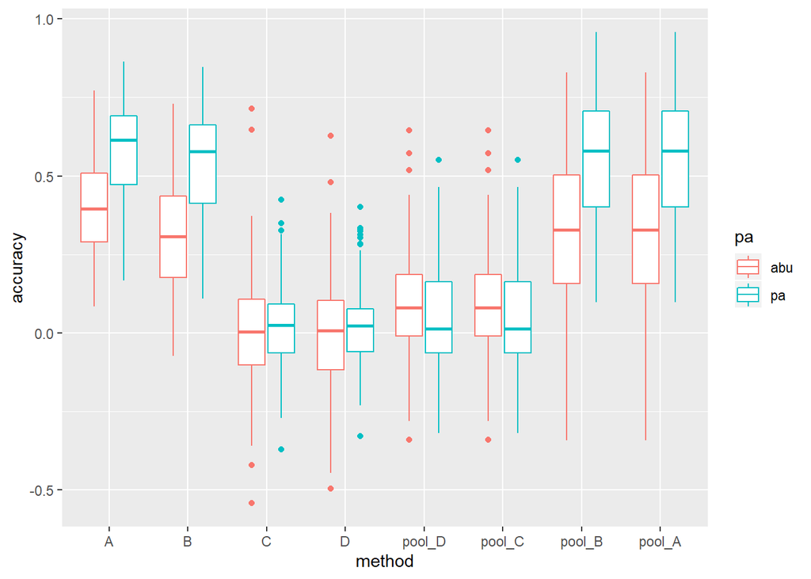

```r
#plottailua
ggplot(res2, aes(x = method, y = accuracy, interaction = pa, colour = pa)) + geom_boxplot()
```

Valitsen aineistosta vain metodi D:n, poolaamattomat ja poolatut ennustustarkkuudet, ja tarkastelen vain niitä vierekkäin.

```r
res3=subset(res2,method=="D"|method=="pool_D")
res3$method=drop.levels(res3$method)
summary(res3)
```

```
##                        species       method       accuracy
##  Acrocephalus_palustris    :  4   D     :240   Min.   :-0.49656
##  Acrocephalus_schoenobaenus:  4   pool_D:240   1st Qu.:-0.05989
##  Acrocephalus_scirpaceus   :  4                Median : 0.03146
##  Actitis_hypoleucos        :  4                Mean   : 0.03836
##  Aegithalos_caudatus       :  4                3rd Qu.: 0.14787
##  Alauda_arvensis           :  4                Max.   : 0.64604
##  (Other)                   :456                NA's   :4
##    pa
##  abu:240
##  pa :240
##
##
##
##
##
```

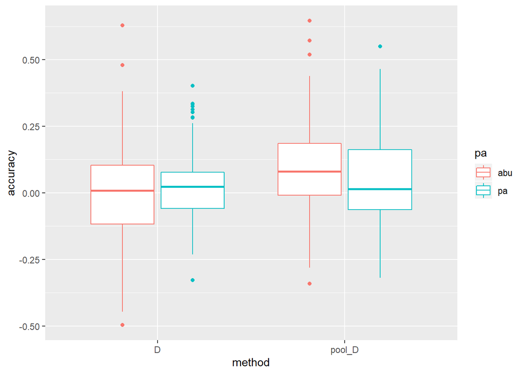

```r
ggplot(res3, aes(x = method, y = accuracy, interaction = pa, colour = pa)) + geom_boxplot()
```

Näyttää siltä, että poolaus on parantanut ennustustarkkuuksia vain hitusen. Tarkastellaan keskiarvoja ja keskivirheitä:

```r
res3%>%
  group_by(method,pa) %>%
  summarise(means=mean(accuracy,na.rm=T),std.errors=std.error(accuracy,na.rm=T))
```

```
## # A tibble: 4 x 4
## # Groups:   method [2]
##   method pa      means std.errors
##   <fct>  <fct>   <dbl>      <dbl>
## 1 D      abu   0.00270     0.0165
## 2 D      pa    0.0239      0.0123
## 3 pool_D abu   0.0851      0.0154
## 4 pool_D pa    0.0419      0.0152
```

Nyt aineistossa siis enää vain metodi D:n arvot.

### 3.3.3 Analyysi

Testataan vaikuttaako poolaus ja aineistotyyppi ennustustarkkuuksiin. Käytän samaa sekamallia kuin aikaisemminkin.(En siis vertaile random-rakenteita enää). Laji on random-muuttuja. Aineistona on kuitenkin vain poolaamattomat ja poolatut metodi D:llä lasketut ennustustarkkuudet (ei A,B,C). Onko tämä oikein?

```r
#fixed osan vertailua
A1=lme(accuracy~method*pa,data=res3,random=~1|species,method="ML",na.action="na.exclude")
A2=lme(accuracy~method+pa,data=res3,random=~1|species,method="ML",na.action="na.exclude")
A3=lme(accuracy~method,data=res3,random=~1|species,method="ML",na.action="na.exclude")
A4=lme(accuracy~pa,data=res3,random=~1|species,method="ML",na.action="na.exclude")

anova(A1,A2)
```

```
##    Model df       AIC       BIC   logLik   Test  L.Ratio p-value
## A1     1  6 -387.4171 -362.4246 199.7086
## A2     2  5 -383.7601 -362.9330 196.8801 1 vs 2 5.657008  0.0174
```

```r
AIC(A1,A2,A3,A4)
```

```
##    df       AIC
## A1  6 -387.4171
## A2  5 -383.7601
## A3  4 -385.1746
## A4  4 -372.4958
```

```r
summary(A1)
```

```
## Linear mixed-effects model fit by maximum likelihood
##  Data: res3
##         AIC       BIC   logLik
##   -387.4171 -362.4246 199.7086
##
## Random effects:
##  Formula: ~1 | species
##         (Intercept)  Residual
## StdDev:  0.06845922 0.1471081
##
## Fixed effects: accuracy ~ method * pa
##                         Value  Std.Error  DF   t-value p-value
## (Intercept)        0.00206311 0.01499344 353  0.137601  0.8906
## methodpool_D       0.08244857 0.01923283 353  4.286866  0.0000
## papa               0.02180065 0.01916468 353  1.137543  0.2561
## methodpool_D:papa -0.06440747 0.02708576 353 -2.377909  0.0179
##  Correlation:
##                   (Intr) mthd_D papa
## methodpool_D      -0.641
## papa              -0.645  0.502
## methodpool_D:papa  0.455 -0.710 -0.707
##
## Standardized Within-Group Residuals:
##          Min           Q1          Med           Q3          Max
## -3.304211245 -0.579455344 -0.009784709  0.579112361  3.902444725
##
## Number of Observations: 476
## Number of Groups: 120
```

```r
anova(A1)
```

```
##             numDF denDF   F-value p-value
## (Intercept)     1   353 16.944492  <.0001
## method          1   353 13.617597  0.0003
## pa              1   353  0.588573  0.4435
## method:pa       1   353  5.654451  0.0179
```

Interaktio näyttäisi olevan merkitsevä.

```r
#lopullinen malli
A1_final=lme(accuracy~method*pa,data=res3,random=~1|species,method="REML",na.action="na.exclude")
summary(A1_final)
```

```
## Linear mixed-effects model fit by REML
##  Data: res3
##         AIC       BIC   logLik
##   -360.9604 -336.0185 186.4802
##
## Random effects:
##  Formula: ~1 | species
##         (Intercept)  Residual
## StdDev:  0.06874676 0.1477307
##
## Fixed effects: accuracy ~ method * pa
##                         Value  Std.Error  DF   t-value p-value
## (Intercept)        0.00206314 0.01499341 353  0.137603  0.8906
## methodpool_D       0.08244857 0.01923290 353  4.286850  0.0000
## papa               0.02180062 0.01916475 353  1.137538  0.2561
## methodpool_D:papa -0.06440747 0.02708586 353 -2.377900  0.0179
##  Correlation:
##                   (Intr) mthd_D papa
## methodpool_D      -0.641
## papa              -0.645  0.502
## methodpool_D:papa  0.455 -0.710 -0.707
##
## Standardized Within-Group Residuals:
##          Min           Q1          Med           Q3          Max
## -3.290289612 -0.577005037 -0.009746084  0.576677638  3.885995943
##
## Number of Observations: 476
## Number of Groups: 120
```

Mallin validointi residuaaleilla:

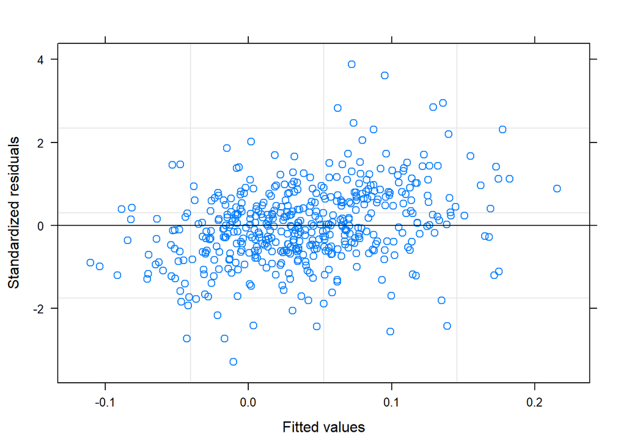

```r
#validointi
plot(A1_final)
```

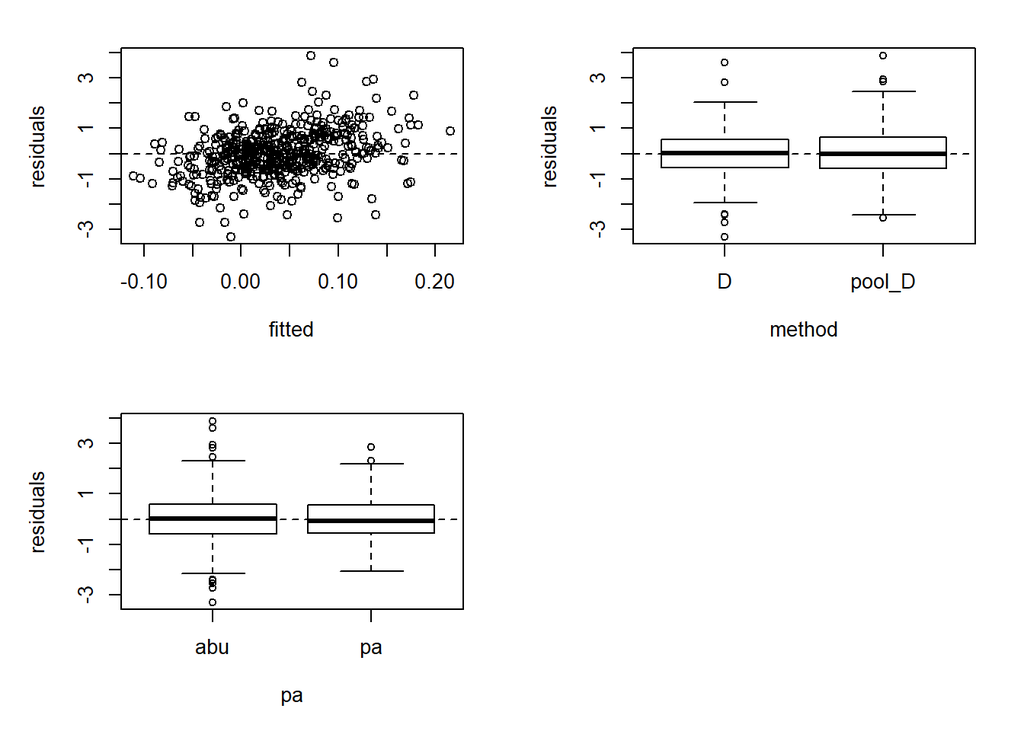

```r
E1=resid(A1_final, type="normalized")
F1=fitted(A1_final)

par(mfrow=c(2,2), mar=c(5,5,2,2))
plot(x=F1,y=E1,xlab="fitted",ylab="residuals")
abline(h=0,lty=2)
boxplot(E1~method,xlab="method",ylab="residuals",data=res3)
abline(h=0,lty=2)
boxplot(E1~pa,xlab="pa",ylab="residuals",data=res3)
abline(h=0,lty=2)
par(mfrow=c(1,1), mar=c(5,5,2,2))
```

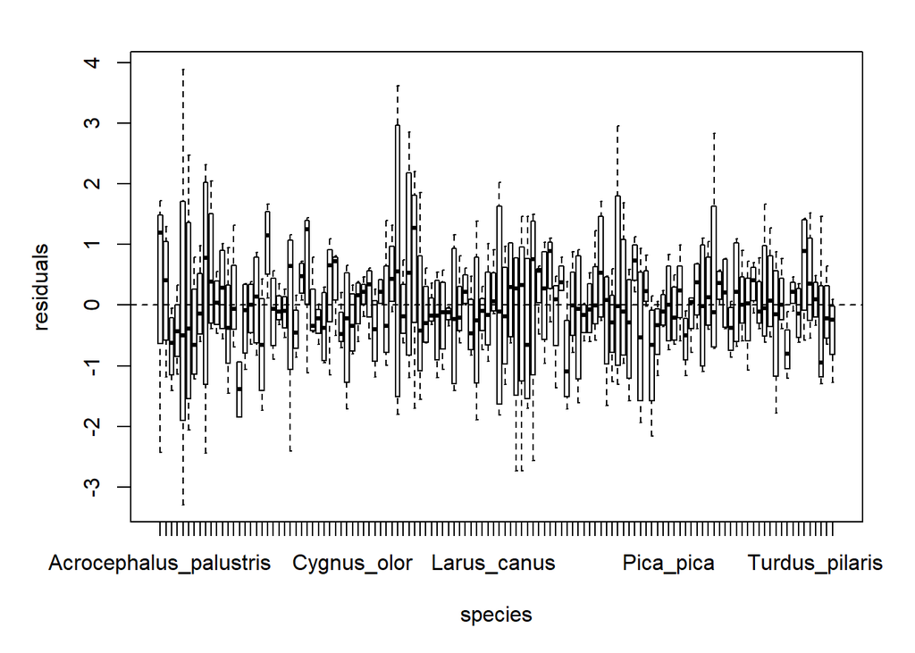

```r
boxplot(E1~species,xlab="species",ylab="residuals",data=res3)
abline(h=0,lty=2)
```

Eli tässäkin on tuloksena, että poolauksen ja aineistotyypin yhdistelmä vaikuttavat ennustustarkkuuteen. Residuaalit ihan ok. Mutta erothan ovat ihan minimaalisia verrattuna muuhun aineistoon.

### verrataan C vs. pool_C

```r
res4=subset(res2,method=="C"|method=="pool_C")
res4$method=drop.levels(res4$method)
summary(res4)
```

```
##                        species       method       accuracy         pa
##  Acrocephalus_palustris    :  4   C     :240   Min.   :-0.5428   abu:240
##  Acrocephalus_schoenobaenus:  4   pool_C:240   1st Qu.:-0.0628   pa :240
##  Acrocephalus_scirpaceus   :  4                Median : 0.0314
##  Actitis_hypoleucos        :  4                Mean   : 0.0405
##  Aegithalos_caudatus       :  4                3rd Qu.: 0.1454
##  Alauda_arvensis           :  4                Max.   : 0.7144
##  (Other)                   :456                NA's   :4
```

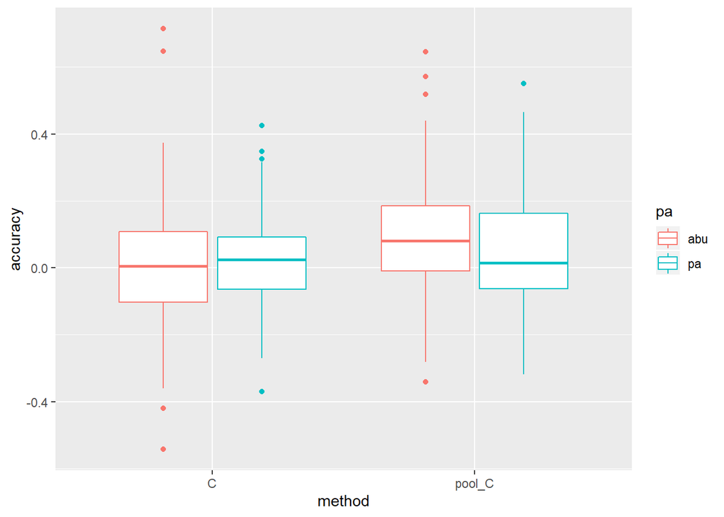

```r
ggplot(res4, aes(x = method, y = accuracy, interaction = pa, colour = pa)) + geom_boxplot()
```

```r
res4%>%
  group_by(method,pa) %>%
  summarise(means=mean(accuracy,na.rm=T),std.errors=std.error(accuracy,na.rm=T))
```

```
## # A tibble: 4 x 4
## # Groups:   method [2]
##   method pa     means std.errors
##   <fct>  <fct>  <dbl>      <dbl>
## 1 C      abu   0.0120     0.0170
## 2 C      pa    0.0232     0.0128
## 3 pool_C abu   0.0851     0.0154
## 4 pool_C pa    0.0419     0.0152
```

```r
#fixed osan vertailua
A1=lme(accuracy~method*pa,data=res4,random=~1|species,method="ML",na.action="na.exclude")
A2=lme(accuracy~method+pa,data=res4,random=~1|species,method="ML",na.action="na.exclude")
A3=lme(accuracy~method,data=res4,random=~1|species,method="ML",na.action="na.exclude")
A4=lme(accuracy~pa,data=res4,random=~1|species,method="ML",na.action="na.exclude")

anova(A1,A2)
```

```
##    Model df       AIC       BIC   logLik   Test  L.Ratio p-value
## A1     1  6 -366.3713 -341.3788 189.1856
## A2     2  5 -364.5908 -343.7637 187.2954 1 vs 2 3.780506  0.0519
```

```r
AIC(A1,A2,A3,A4)
```

```
##    df       AIC
## A1  6 -366.3713
## A2  5 -364.5908
## A3  4 -365.3831
## A4  4 -356.1784
```

```r
summary(A1)
```

```
## Linear mixed-effects model fit by maximum likelihood
##  Data: res4
##         AIC       BIC   logLik
##   -366.3713 -341.3788 189.1856
##
## Random effects:
##  Formula: ~1 | species
##         (Intercept)  Residual
## StdDev:  0.06252884 0.1524739
##
## Fixed effects: accuracy ~ method * pa
##                         Value  Std.Error  DF   t-value p-value
## (Intercept)        0.01145616 0.01523036 353  0.752192  0.4524
## methodpool_C       0.07315771 0.01993434 353  3.669933  0.0003
## papa               0.01179163 0.01986160 353  0.593689  0.5531
## methodpool_C:papa -0.05450064 0.02807371 353 -1.941341  0.0530
##  Correlation:
##                   (Intr) mthd_C papa
## methodpool_C      -0.654
## papa              -0.658  0.502
## methodpool_C:papa  0.465 -0.710 -0.707
##
## Standardized Within-Group Residuals:
##         Min          Q1         Med          Q3         Max
## -3.47390518 -0.55450908 -0.01729064  0.56738576  4.09722305
##
## Number of Observations: 476
## Number of Groups: 120
```

```r
anova(A1)
```

```
##             numDF denDF   F-value p-value
## (Intercept)     1   353 19.680196  <.0001
## method          1   353 10.590409  0.0012
## pa              1   353  1.210287  0.2720
## method:pa       1   353  3.768804  0.0530
```

### verrataan B vs. pool_B

```r
res5=subset(res2,method=="B"|method=="pool_B")
res5$method=drop.levels(res5$method)
summary(res5)
```

```
##                        species       method       accuracy         pa
##  Acrocephalus_palustris    :  4   B     :240   Min.   :-0.3422   abu:240
##  Acrocephalus_schoenobaenus:  4   pool_B:240   1st Qu.: 0.2556   pa :240
##  Acrocephalus_scirpaceus   :  4                Median : 0.4329
##  Actitis_hypoleucos        :  4                Mean   : 0.4317
##  Aegithalos_caudatus       :  4                3rd Qu.: 0.6235
##  Alauda_arvensis           :  4                Max.   : 0.9579
##  (Other)                   :456
```

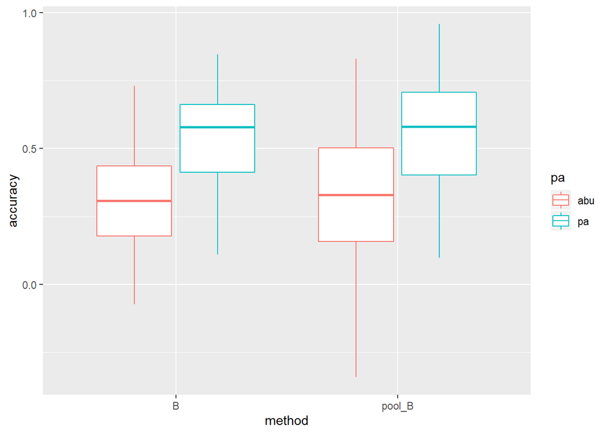

```r
ggplot(res5, aes(x = method, y = accuracy, interaction = pa, colour = pa)) + geom_boxplot()
```

```r
res5%>%
  group_by(method,pa) %>%
  summarise(means=mean(accuracy,na.rm=T),std.errors=std.error(accuracy,na.rm=T))
```

```
## # A tibble: 4 x 4
## # Groups:   method [2]
##   method pa    means std.errors
##   <fct>  <fct> <dbl>      <dbl>
## 1 B      abu   0.313     0.0171
## 2 B      pa    0.536     0.0164
## 3 pool_B abu   0.327     0.0213
## 4 pool_B pa    0.551     0.0187
```

```r
#fixed osan vertailua
A1=lme(accuracy~method*pa,data=res5,random=~1|species,method="ML",na.action="na.exclude")
A2=lme(accuracy~method+pa,data=res5,random=~1|species,method="ML",na.action="na.exclude")
A3=lme(accuracy~method,data=res5,random=~1|species,method="ML",na.action="na.exclude")
A4=lme(accuracy~pa,data=res5,random=~1|species,method="ML",na.action="na.exclude")

anova(A1,A2)
```

```
##    Model df       AIC       BIC   logLik   Test     L.Ratio p-value
## A1     1  6 -392.9464 -367.9037 202.4732
## A2     2  5 -394.9453 -374.0764 202.4727 1 vs 2 0.001067306  0.9739
```

```r
AIC(A1,A2,A3,A4)
```

```
##    df       AIC
## A1  6 -392.9464
## A2  5 -394.9453
## A3  4 -129.9125
## A4  4 -395.1448
```

```r
summary(A1)
```

```
## Linear mixed-effects model fit by maximum likelihood
##  Data: res5
##         AIC       BIC   logLik
##   -392.9464 -367.9037 202.4732
##
## Random effects:
##  Formula: ~1 | species
##         (Intercept)  Residual
## StdDev:   0.1596939 0.1228384
##
## Fixed effects: accuracy ~ method * pa
##                        Value  Std.Error  DF   t-value p-value
## (Intercept)       0.31279760 0.01846901 357 16.936352  0.0000
## methodpool_B      0.01469905 0.01592486 357  0.923025  0.3566
## papa              0.22274269 0.01592486 357 13.987108  0.0000
## methodpool_B:papa 0.00073269 0.02252115 357  0.032533  0.9741
##  Correlation:
##                   (Intr) mthd_B papa
## methodpool_B      -0.431
## papa              -0.431  0.500
## methodpool_B:papa  0.305 -0.707 -0.707
##
## Standardized Within-Group Residuals:
##         Min          Q1         Med          Q3         Max
## -4.57186107 -0.49925821  0.02080284  0.53001455  2.70031279
##
## Number of Observations: 480
## Number of Groups: 120
```

```r
anova(A1)
```

```
##             numDF denDF  F-value p-value
## (Intercept)     1   357 757.5749  <.0001
## method          1   357   1.7899  0.1818
## pa              1   357 392.5665  <.0001
## method:pa       1   357   0.0011  0.9741
```

### verrataan A vs. pool_A

```r
res6=subset(res2,method=="A"|method=="pool_A")
res6$method=drop.levels(res6$method)
summary(res6)
```

```
##                        species       method       accuracy         pa
##  Acrocephalus_palustris    :  4   A     :240   Min.   :-0.3422   abu:240
##  Acrocephalus_schoenobaenus:  4   pool_A:240   1st Qu.: 0.3174   pa :240
##  Acrocephalus_scirpaceus   :  4                Median : 0.4725
##  Actitis_hypoleucos        :  4                Mean   : 0.4647
##  Aegithalos_caudatus       :  4                3rd Qu.: 0.6439
##  Alauda_arvensis           :  4                Max.   : 0.9579
##  (Other)                   :456
```

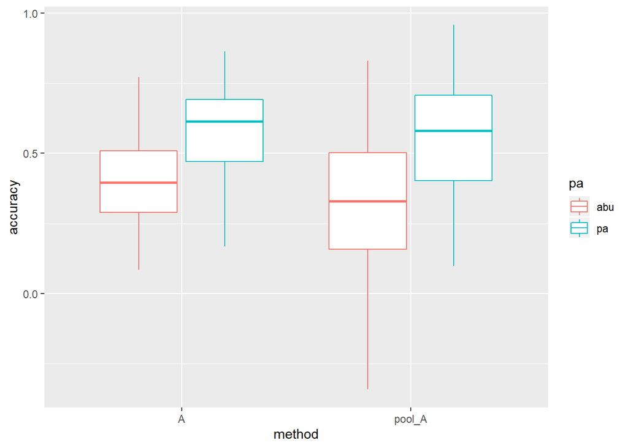

```r
ggplot(res6, aes(x = method, y = accuracy, interaction = pa, colour = pa)) + geom_boxplot()
```

```r
res6%>%
  group_by(method,pa) %>%
  summarise(means=mean(accuracy,na.rm=T),std.errors=std.error(accuracy,na.rm=T))
```

```
## # A tibble: 4 x 4
## # Groups:   method [2]
##   method pa    means std.errors
##   <fct>  <fct> <dbl>      <dbl>
## 1 A      abu   0.405     0.0149
## 2 A      pa    0.575     0.0153
## 3 pool_A abu   0.327     0.0213
## 4 pool_A pa    0.551     0.0187
```

```r
#fixed osan vertailua
A1=lme(accuracy~method*pa,data=res6,random=~1|species,method="ML",na.action="na.exclude")
A2=lme(accuracy~method+pa,data=res6,random=~1|species,method="ML",na.action="na.exclude")
A3=lme(accuracy~method,data=res6,random=~1|species,method="ML",na.action="na.exclude")
A4=lme(accuracy~pa,data=res6,random=~1|species,method="ML",na.action="na.exclude")

anova(A1,A2)
```

```
##    Model df       AIC       BIC   logLik   Test  L.Ratio p-value
## A1     1  6 -426.1817 -401.1390 219.0908
## A2     2  5 -422.0489 -401.1799 216.0244 1 vs 2 6.132828  0.0133
```

```r
AIC(A1,A2,A3,A4)
```

```
##    df       AIC
## A1  6 -426.1817
## A2  5 -422.0489
## A3  4 -194.3345
## A4  4 -403.0503
```

```r
summary(A1)
```

```
## Linear mixed-effects model fit by maximum likelihood
##  Data: res6
##         AIC      BIC   logLik
##   -426.1817 -401.139 219.0908
##
## Random effects:
##  Formula: ~1 | species
##         (Intercept)  Residual
## StdDev:   0.1525954 0.1190166
##
## Fixed effects: accuracy ~ method * pa
##                        Value  Std.Error  DF   t-value p-value
## (Intercept)        0.4054711 0.01774002 357 22.856292  0.0000
## methodpool_A      -0.0779745 0.01542940 357 -5.053632  0.0000
## papa               0.1694336 0.01542940 357 10.981220  0.0000
## methodpool_A:papa  0.0540418 0.02182046 357  2.476655  0.0137
##  Correlation:
##                   (Intr) mthd_A papa
## methodpool_A      -0.435
## papa              -0.435  0.500
## methodpool_A:papa  0.308 -0.707 -0.707
##
## Standardized Within-Group Residuals:
##         Min          Q1         Med          Q3         Max
## -4.91003514 -0.53208383  0.03866461  0.51463700  2.65501463
##
## Number of Observations: 480
## Number of Groups: 120
```

```r
anova(A1)
```

```
##             numDF denDF  F-value p-value
## (Intercept)     1   357 957.9606  <.0001
## method          1   357  21.8113  <.0001
## pa              1   357 324.2321  <.0001
## method:pa       1   357   6.1338  0.0137
```

### Analyysi kaikilla poolatuilla metodeilla

```r
#aineisto uusiksi
poolres=res2
poolres$pool=NA

poolres$pool[poolres$method == "A"  | poolres$method == "B" | poolres$method == "C" | poolres$method == "D"] <- "NPo"
poolres$pool[poolres$method == "pool_A"  | poolres$method == "pool_B" | poolres$method == "pool_C" | poolres$method == "pool_D"] <- "Po"

poolres$method <- stringr::str_replace(poolres$method, 'pool_', '')

#tarkistellaan taulukkona
poolres%>%
  group_by(method,pa,pool) %>%
  summarise(means=mean(accuracy,na.rm=T),std.errors=std.error(accuracy,na.rm=T))
```

```
## # A tibble: 16 x 5
## # Groups:   method, pa [8]
##    method pa    pool    means std.errors
##    <chr>  <fct> <chr>   <dbl>      <dbl>
##  1 A      abu   NPo   0.405       0.0149
##  2 A      abu   Po    0.327       0.0213
##  3 A      pa    NPo   0.575       0.0153
##  4 A      pa    Po    0.551       0.0187
##  5 B      abu   NPo   0.313       0.0171
##  6 B      abu   Po    0.327       0.0213
##  7 B      pa    NPo   0.536       0.0164
##  8 B      pa    Po    0.551       0.0187
##  9 C      abu   NPo   0.0120      0.0170
## 10 C      abu   Po    0.0851      0.0154
## 11 C      pa    NPo   0.0232      0.0128
## 12 C      pa    Po    0.0419      0.0152
## 13 D      abu   NPo   0.00270     0.0165
## 14 D      abu   Po    0.0851      0.0154
## 15 D      pa    NPo   0.0239      0.0123
## 16 D      pa    Po    0.0419      0.0152
```

```r
#fixed osan vertailua
A1=lme(accuracy~method*pa*pool,data=poolres,random=~1|species,method="ML",na.action="na.exclude")
A2=lme(accuracy~method*pa+method*pool+pool*pa,data=poolres,random=~1|species,method="ML",na.action="na.exclude")
#A3=lme(accuracy~method,data=poolres,random=~1|species,method="ML",na.action="na.exclude")
#A4=lme(accuracy~pa,data=poolres,random=~1|species,method="ML",na.action="na.exclude")

anova(A1,A2)
```

```
##    Model df       AIC       BIC   logLik   Test  L.Ratio p-value
## A1     1 18 -1545.927 -1445.921 790.9637
## A2     2 15 -1539.928 -1456.590 784.9643 1 vs 2 11.99888  0.0074
```

```r
#AIC(A1,A2,A3,A4)

summary(A1)
```

```
## Linear mixed-effects model fit by maximum likelihood
##  Data: poolres
##         AIC       BIC   logLik
##   -1545.927 -1445.921 790.9637
##
## Random effects:
##  Formula: ~1 | species
##         (Intercept)  Residual
## StdDev:   0.1028895 0.1495826
##
## Fixed effects: accuracy ~ method * pa * pool
##                          Value  Std.Error   DF    t-value p-value
## (Intercept)          0.4054711 0.01664316 1777  24.362632  0.0000
## methodB             -0.0926735 0.01939234 1777  -4.778873  0.0000
## methodC             -0.3954135 0.01948014 1777 -20.298292  0.0000
## methodD             -0.4047043 0.01948014 1777 -20.775233  0.0000
## papa                 0.1694336 0.01939234 1777   8.737141  0.0000
## poolPo              -0.0779745 0.01939234 1777  -4.020891  0.0001
## methodB:papa         0.0533091 0.02742491 1777   1.943819  0.0521
## methodC:papa        -0.1562435 0.02748706 1777  -5.684256  0.0000
## methodD:papa        -0.1463367 0.02748706 1777  -5.323838  0.0000
## methodB:poolPo       0.0926735 0.02742491 1777   3.379174  0.0007
## methodC:poolPo       0.1511322 0.02754087 1777   5.487560  0.0000
## methodD:poolPo       0.1604231 0.02754087 1777   5.824908  0.0000
## papa:poolPo          0.0540418 0.02742491 1777   1.970535  0.0489
## methodB:papa:poolPo -0.0533091 0.03878468 1777  -1.374488  0.1695
## methodC:papa:poolPo -0.1085424 0.03886677 1777  -2.792679  0.0053
## methodD:papa:poolPo -0.1184492 0.03886677 1777  -3.047571  0.0023
##  Correlation:
##                     (Intr) methdB methdC methdD papa   poolPo mthdB:
## methodB             -0.583
## methodC             -0.580  0.498
## methodD             -0.580  0.498  0.496
## papa                -0.583  0.500  0.498  0.498
## poolPo              -0.583  0.500  0.498  0.498  0.500
## methodB:papa         0.412 -0.707 -0.352 -0.352 -0.707 -0.354
## methodC:papa         0.411 -0.353 -0.709 -0.352 -0.706 -0.353  0.499
## methodD:papa         0.411 -0.353 -0.352 -0.709 -0.706 -0.353  0.499
## methodB:poolPo       0.412 -0.707 -0.352 -0.352 -0.354 -0.707  0.500
## methodC:poolPo       0.410 -0.352 -0.707 -0.350 -0.352 -0.704  0.249
```

[output cut: 29 more lines]

```
## methodD:papa
## methodB:poolPo
## methodC:poolPo
## methodD:poolPo
## papa:poolPo
## methodB:papa:poolPo
## methodC:papa:poolPo
## methodD:papa:poolPo  0.498
##
## Standardized Within-Group Residuals:
##         Min          Q1         Med          Q3         Max
## -3.96291962 -0.57075929  0.06833639  0.60971398  4.62494944
##
## Number of Observations: 1912
## Number of Groups: 120
```

```r
anova(A1)
```

```
##                numDF denDF   F-value p-value
## (Intercept)        1  1777  592.8439  <.0001
## method             3  1777 1188.0356  <.0001
## pa                 1  1777  210.3091  <.0001
## pool               1  1777    4.6424  0.0313
## method:pa          3  1777   87.0509  <.0001
## method:pool        3  1777   11.5159  <.0001
## pa:pool            1  1777    1.3305  0.2489
## method:pa:pool     3  1777    3.9795  0.0077
```

Onkohan tämä kolmen muuttujan interaktio järkevä? Onko parempi analysoida kukin metodi erikseen (kuten yllä)?

### 3.3.4 Muita testailuja

#### 3.3.4.1 ANOVA

```r
#the test
res.aov <- anova_test(
  data = res3, dv = accuracy, wid = species,
  within = c(pa, method)
  )
get_anova_table(res.aov)
```

```
## ANOVA Table (type III tests)
##
##      Effect DFn DFd      F        p p<.05      ges
## 1        pa   1 117  0.243 6.23e-01       0.000765
## 2    method   1 117 22.081 7.19e-06     * 0.024000
## 3 pa:method   1 117  9.150 3.00e-03     * 0.009000
```

```r
# Effect of method at both data types
one.way <- res3 %>%
  group_by(pa) %>%
  anova_test(dv = accuracy, wid = species, within = method) %>%
  get_anova_table() %>%
  adjust_pvalue(method = "bonferroni")
one.way
```

```
## # A tibble: 2 x 9
##   pa    Effect   DFn   DFd     F         p `p<.05`   ges    p.adj
##   <fct> <chr>  <dbl> <dbl> <dbl>     <dbl> <chr>   <dbl>    <dbl>
## 1 abu   method     1   117 17.3  0.0000605 *       0.054 0.000121
## 2 pa    method     1   119  5.54 0.02      *       0.004 0.04
```

Sekä pa että abu aineistolla metodilla on väliä.

```r
# Pairwise comparisons between methods
pwc <- res3 %>%
  group_by(pa) %>%
  pairwise_t_test(
    accuracy ~ method, paired = TRUE,
    p.adjust.method = "bonferroni"
    )
pwc
```

```
## # A tibble: 2 x 11
##   pa    .y.   group1 group2    n1    n2 statistic    df       p   p.adj
## * <fct> <chr> <chr>  <chr>  <int> <int>     <dbl> <dbl>   <dbl>   <dbl>
## 1 abu   accu~ D      pool_D   120   120     -4.16   117 6.05e-5 6.05e-5
## 2 pa    accu~ D      pool_D   120   120     -2.35   119 2.00e-2 2.00e-2
## # ... with 1 more variable: p.adj.signif <chr>
```

Sama tulos kuin yllä koska vain kaksi metodia vertailtavana.

```r
# Pairwise comparisons between data types
pwc <- res3 %>%
  group_by(method) %>%
  pairwise_t_test(
    accuracy ~ pa, paired = TRUE,
    p.adjust.method = "bonferroni"
    )
pwc
```

```
## # A tibble: 2 x 11
##   method .y.   group1 group2    n1    n2 statistic    df     p p.adj
## * <fct>  <chr> <chr>  <chr>  <int> <int>     <dbl> <dbl> <dbl> <dbl>
## 1 D      accu~ abu    pa       120   120     -1.08   117 0.282 0.282
## 2 pool_D accu~ abu    pa       120   120      1.92   117 0.058 0.058
## # ... with 1 more variable: p.adj.signif <chr>
```

Aineistotyypillä sen sijaan ei ole niin suurta vaikutusta. Oli aineisto poolattu tai ei, kummatkin aineistotyypit, sekä pa että abu, antavat yhtä “huonoja” ennustustarkkuuksia.

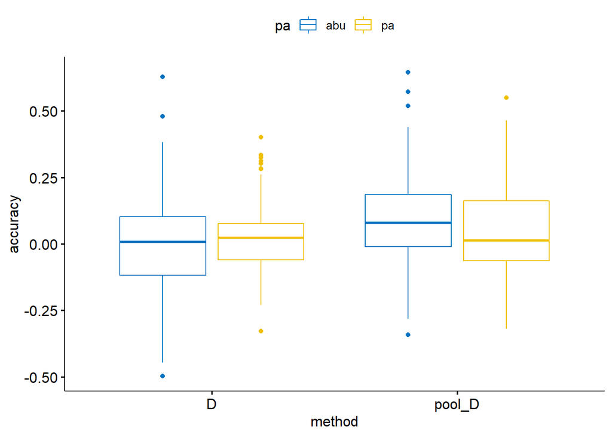

```r
#visualization
bxp <- ggboxplot(
  res3, x = "method", y = "accuracy",
  color = "pa", palette = "jco"
  )
bxp
```

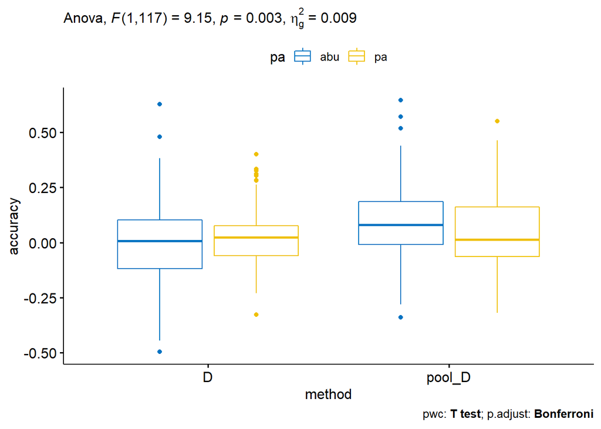

```r
# Visualization: box plots with p-values
pwc <- pwc %>% add_xy_position(x = "method")
bxp +
  stat_pvalue_manual(pwc, tip.length = 0, hide.ns = TRUE) +
  labs(
    subtitle = get_test_label(res.aov, detailed = TRUE),
    caption = get_pwc_label(pwc)
  )
```

#### 3.3.4.2 Luottamusvälit

```r
stat <- summarySE(res3, measurevar="accuracy", groupvars=c("method","pa"),na.rm = T)
stat
```

```
##   method  pa   N    accuracy        sd         se         ci
## 1      D abu 118 0.002695576 0.1797458 0.01654694 0.03277035
## 2      D  pa 120 0.023863762 0.1345628 0.01228385 0.02432325
## 3 pool_D abu 118 0.085144143 0.1670662 0.01537969 0.03045867
## 4 pool_D  pa 120 0.041904857 0.1670504 0.01524954 0.03019562
```

```r
stat$lower=stat$accuracy-stat$ci
stat$upper=stat$accuracy+stat$ci
names(stat)[2] <- "Data_type"
stat$method=revalue(stat$method, c("D"="D", "pool_D"="pooled D"))
knitr::kable(stat)
```

| method | Data_type | N | accuracy | sd | se | ci | lower | upper |
| --- | --- | --- | --- | --- | --- | --- | --- | --- |
| D | abu | 118 | 0.0026956 | 0.1797458 | 0.0165469 | 0.0327704 | -0.0300748 | 0.0354659 |
| D | pa | 120 | 0.0238638 | 0.1345628 | 0.0122838 | 0.0243232 | -0.0004595 | 0.0481870 |
| pooled D | abu | 118 | 0.0851441 | 0.1670662 | 0.0153797 | 0.0304587 | 0.0546855 | 0.1156028 |
| pooled D | pa | 120 | 0.0419049 | 0.1670504 | 0.0152495 | 0.0301956 | 0.0117092 | 0.0721005 |

[output not shown]

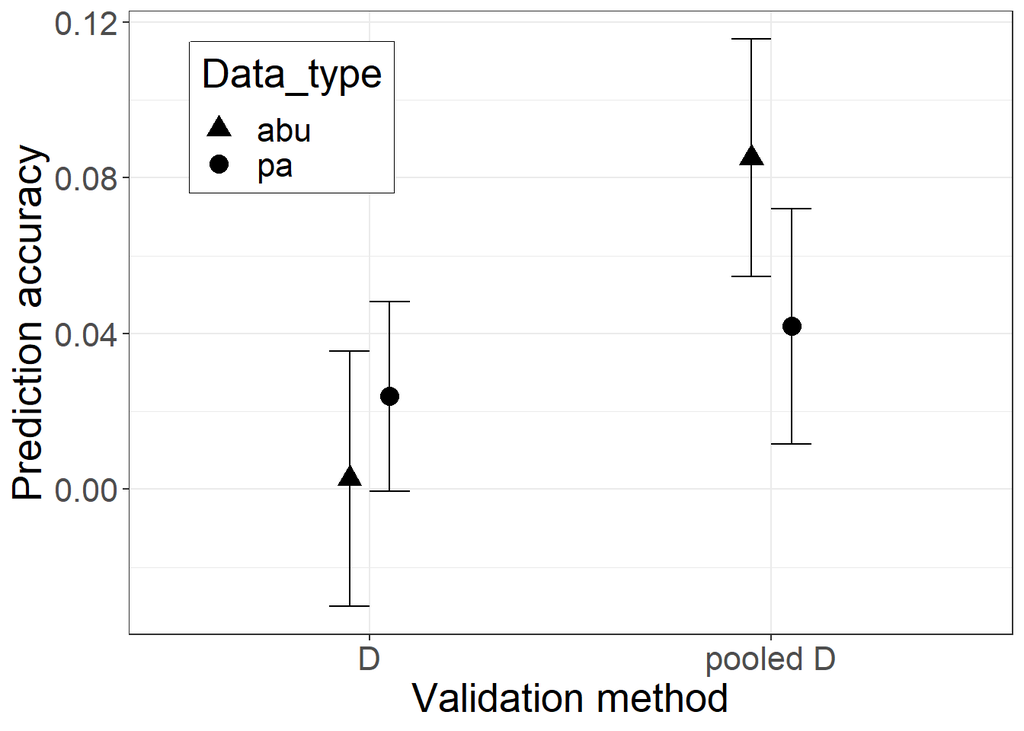

```r
names(res3)[4] <- "Data_type"
res3$method=revalue(res3$method, c("D"="D", "pool_D"="pooled D"))
pd <- position_dodge(0.2) # move them .05 to the left and right
# Black error bars - notice the mapping of 'group=supp' -- without it, the error
# bars won't be dodged!

#ggplot(stat, aes(x=method, y=accuracy, group=Data_type)) +
#    geom_errorbar(aes(ymin=accuracy-ci, ymax=accuracy+ci), colour="black", width=.2, position=pd) +
#    geom_point(aes(shape=Data_type),position=pd, size=4)+
#    scale_shape_manual(values=c(19,17))+
#    ylab("Prediction accuracy") +
##    xlab("Validation method") +
#    theme_bw() +
#    theme(legend.justification=c(1,1),
#          legend.position=c(0.3,0.95),
#          legend.box.background=element_rect())  +             # Position legend in bottom right
#    theme(text = element_text(size = 17)) +
#    labs(fill = "Data type")

ggplot(stat, aes(y=accuracy, x=method,shape=Data_type)) + geom_errorbar(aes(ymin=accuracy-ci, ymax=accuracy+ci), colour="black", width=.2, position=pd) +ylab("Prediction accuracy") +
    xlab("Validation method") +
    theme_bw() +
    theme(legend.justification=c(1,1),
          legend.position=c(0.3,0.95),
          legend.box.background=element_rect())  +
    theme(text = element_text(size = 20)) +
    geom_point(position=pd, size=4) +  scale_shape_discrete(name = "Data type", labels = c("abu", "POC")) + scale_shape_manual(values=c(17,19))
```

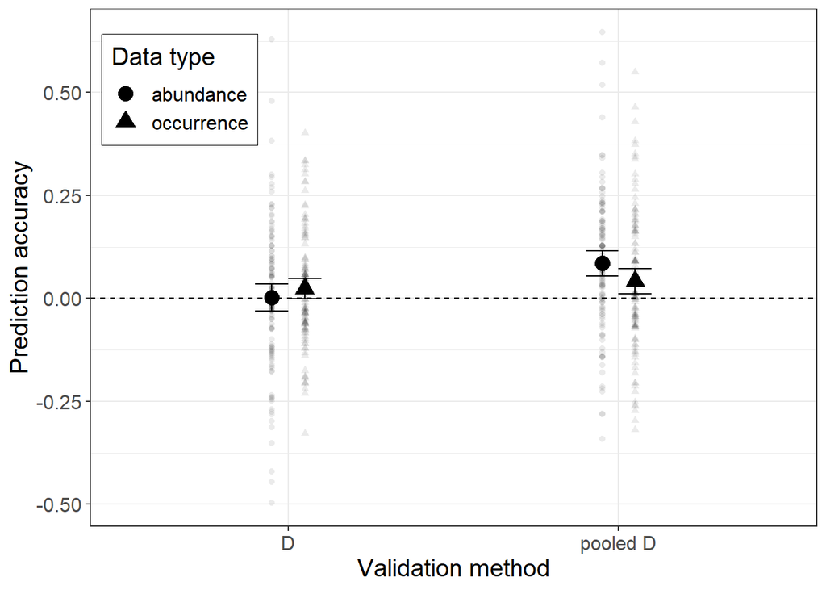

```r
ggsave("plot2_simple.png")
ggplot(stat, aes(y=accuracy, x=method,shape=Data_type)) +
  geom_errorbar(aes(ymin=accuracy-ci, ymax=accuracy+ci), colour="black", width=.2, position=pd) +
  ylab("Prediction accuracy") +
    xlab("Validation method") +
    theme_bw() +
    theme(legend.justification=c(1,1),
          legend.position=c(0.23,0.95),
          legend.box.background=element_rect())  +
    theme(text = element_text(size = 15)) +
    geom_point(position=pd, size=4) +
  scale_shape_discrete(name = "Data type", labels = c("abundance", "occurrence")) + geom_hline(yintercept = 0, linetype="dashed")+
  geom_point(data=res3,position=pd, alpha=0.08)
```

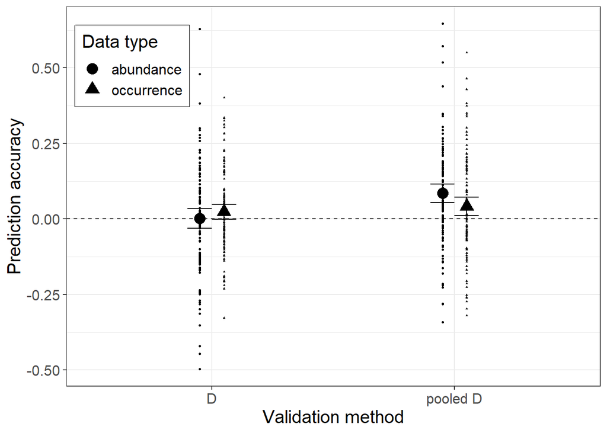

```r
ggsave("plot2_alpha.png")
ggplot(stat, aes(y=accuracy, x=method,shape=Data_type)) +
  geom_errorbar(aes(ymin=accuracy-ci, ymax=accuracy+ci), colour="black", width=.2, position=pd) +
  ylab("Prediction accuracy") +
    xlab("Validation method") +
    theme_bw() +
    theme(legend.justification=c(1,1),
          legend.position=c(0.23,0.95),
          legend.box.background=element_rect())  +
    theme(text = element_text(size = 15)) +
    geom_point(position=pd, size=4) +
  scale_shape_discrete(name = "Data type", labels = c("abundance", "occurrence")) + geom_hline(yintercept = 0, linetype="dashed")+
  geom_point(data=res3,position=pd, size=0.5)
```

```r
ggsave("plot2_noalpha.png")
stat <- summarySE(res2, measurevar="accuracy", groupvars=c("method","pa"),na.rm = T)
stat
```

```
##    method  pa   N    accuracy        sd         se         ci
## 1       A abu 120 0.405471135 0.1628117 0.01486261 0.02942945
## 2       A  pa 120 0.574904752 0.1676330 0.01530273 0.03030093
## 3       B abu 120 0.312797596 0.1870312 0.01707354 0.03380731
## 4       B  pa 120 0.535540286 0.1797158 0.01640573 0.03248499
## 5       C abu 118 0.011986434 0.1850550 0.01703570 0.03373830
## 6       C  pa 120 0.023247787 0.1398196 0.01276373 0.02527346
## 7       D abu 118 0.002695576 0.1797458 0.01654694 0.03277035
## 8       D  pa 120 0.023863762 0.1345628 0.01228385 0.02432325
## 9  pool_D abu 118 0.085144143 0.1670662 0.01537969 0.03045867
## 10 pool_D  pa 120 0.041904857 0.1670504 0.01524954 0.03019562
## 11 pool_C abu 118 0.085144143 0.1670662 0.01537969 0.03045867
## 12 pool_C  pa 120 0.041904857 0.1670504 0.01524954 0.03019562
## 13 pool_B abu 120 0.327496642 0.2331769 0.02128604 0.04214848
## 14 pool_B  pa 120 0.550972018 0.2051344 0.01872612 0.03707959
## 15 pool_A abu 120 0.327496642 0.2331769 0.02128604 0.04214848
## 16 pool_A  pa 120 0.550972018 0.2051344 0.01872612 0.03707959
```

```r
stat$lower=stat$accuracy-stat$ci
stat$upper=stat$accuracy+stat$ci
names(stat)[2] <- "Data_type"
stat$method=revalue(stat$method, c("D"="D", "pool_D"="pooled D"))
knitr::kable(stat)
```

| method | Data_type | N | accuracy | sd | se | ci | lower | upper |
| --- | --- | --- | --- | --- | --- | --- | --- | --- |
| A | abu | 120 | 0.4054711 | 0.1628117 | 0.0148626 | 0.0294295 | 0.3760417 | 0.4349006 |
| A | pa | 120 | 0.5749048 | 0.1676330 | 0.0153027 | 0.0303009 | 0.5446038 | 0.6052057 |
| B | abu | 120 | 0.3127976 | 0.1870312 | 0.0170735 | 0.0338073 | 0.2789903 | 0.3466049 |
| B | pa | 120 | 0.5355403 | 0.1797158 | 0.0164057 | 0.0324850 | 0.5030553 | 0.5680253 |
| C | abu | 118 | 0.0119864 | 0.1850550 | 0.0170357 | 0.0337383 | -0.0217519 | 0.0457247 |
| C | pa | 120 | 0.0232478 | 0.1398196 | 0.0127637 | 0.0252735 | -0.0020257 | 0.0485212 |
| D | abu | 118 | 0.0026956 | 0.1797458 | 0.0165469 | 0.0327704 | -0.0300748 | 0.0354659 |
| D | pa | 120 | 0.0238638 | 0.1345628 | 0.0122838 | 0.0243232 | -0.0004595 | 0.0481870 |
| pooled D | abu | 118 | 0.0851441 | 0.1670662 | 0.0153797 | 0.0304587 | 0.0546855 | 0.1156028 |
| pooled D | pa | 120 | 0.0419049 | 0.1670504 | 0.0152495 | 0.0301956 | 0.0117092 | 0.0721005 |
| pool_C | abu | 118 | 0.0851441 | 0.1670662 | 0.0153797 | 0.0304587 | 0.0546855 | 0.1156028 |
| pool_C | pa | 120 | 0.0419049 | 0.1670504 | 0.0152495 | 0.0301956 | 0.0117092 | 0.0721005 |
| pool_B | abu | 120 | 0.3274966 | 0.2331769 | 0.0212860 | 0.0421485 | 0.2853482 | 0.3696451 |
| pool_B | pa | 120 | 0.5509720 | 0.2051344 | 0.0187261 | 0.0370796 | 0.5138924 | 0.5880516 |
| pool_A | abu | 120 | 0.3274966 | 0.2331769 | 0.0212860 | 0.0421485 | 0.2853482 | 0.3696451 |
| pool_A | pa | 120 | 0.5509720 | 0.2051344 | 0.0187261 | 0.0370796 | 0.5138924 | 0.5880516 |

[output not shown]

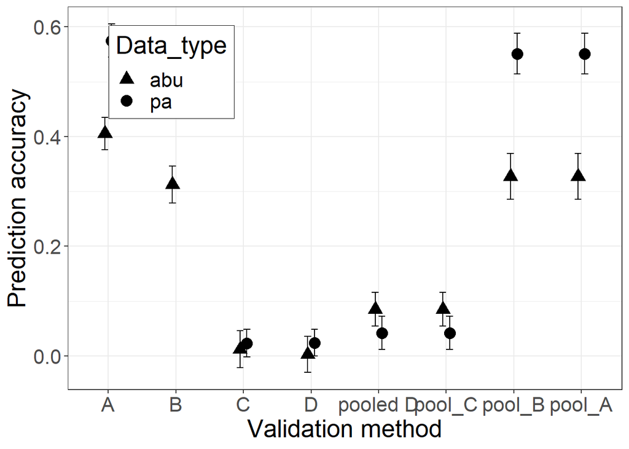

```r
names(res2)[4] <- "Data_type"
res2$method=revalue(res2$method, c("D"="D", "pool_D"="pooled D"))
pd <- position_dodge(0.2) # move them .05 to the left and right
# Black error bars - notice the mapping of 'group=supp' -- without it, the error
# bars won't be dodged!

#ggplot(stat, aes(x=method, y=accuracy, group=Data_type)) +
#    geom_errorbar(aes(ymin=accuracy-ci, ymax=accuracy+ci), colour="black", width=.2, position=pd) +
#    geom_point(aes(shape=Data_type),position=pd, size=4)+
#    scale_shape_manual(values=c(19,17))+
#    ylab("Prediction accuracy") +
##    xlab("Validation method") +
#    theme_bw() +
#    theme(legend.justification=c(1,1),
#          legend.position=c(0.3,0.95),
#          legend.box.background=element_rect())  +             # Position legend in bottom right
#    theme(text = element_text(size = 17)) +
#    labs(fill = "Data type")

ggplot(stat, aes(y=accuracy, x=method,shape=Data_type)) + geom_errorbar(aes(ymin=accuracy-ci, ymax=accuracy+ci), colour="black", width=.2, position=pd) +ylab("Prediction accuracy") +
    xlab("Validation method") +
    theme_bw() +
    theme(legend.justification=c(1,1),
          legend.position=c(0.3,0.95),
          legend.box.background=element_rect())  +
    theme(text = element_text(size = 20)) +
    geom_point(position=pd, size=4) +  scale_shape_discrete(name = "Data type", labels = c("abu", "POC")) + scale_shape_manual(values=c(17,19))
```

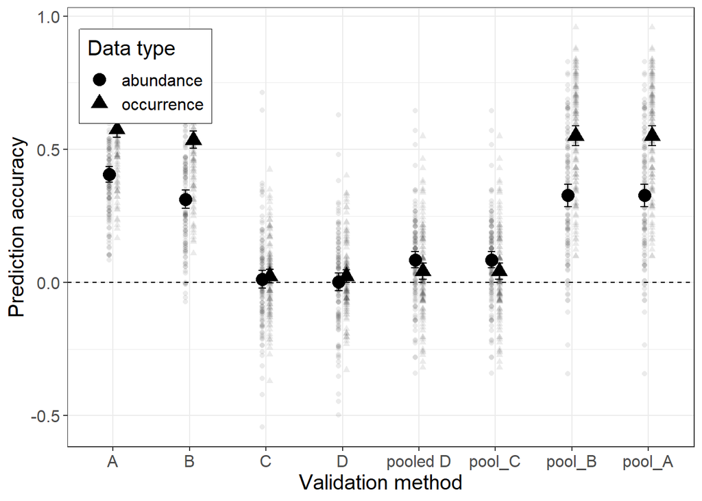

```r
ggsave("plot2_allmethods_simple.png")
ggplot(stat, aes(y=accuracy, x=method,shape=Data_type)) +
  geom_errorbar(aes(ymin=accuracy-ci, ymax=accuracy+ci), colour="black", width=.2, position=pd) +
  ylab("Prediction accuracy") +
    xlab("Validation method") +
    theme_bw() +
    theme(legend.justification=c(1,1),
          legend.position=c(0.23,0.95),
          legend.box.background=element_rect())  +
    theme(text = element_text(size = 15)) +
    geom_point(position=pd, size=4) +
  scale_shape_discrete(name = "Data type", labels = c("abundance", "occurrence")) + geom_hline(yintercept = 0, linetype="dashed")+
  geom_point(data=res2,position=pd, alpha=0.08)
```

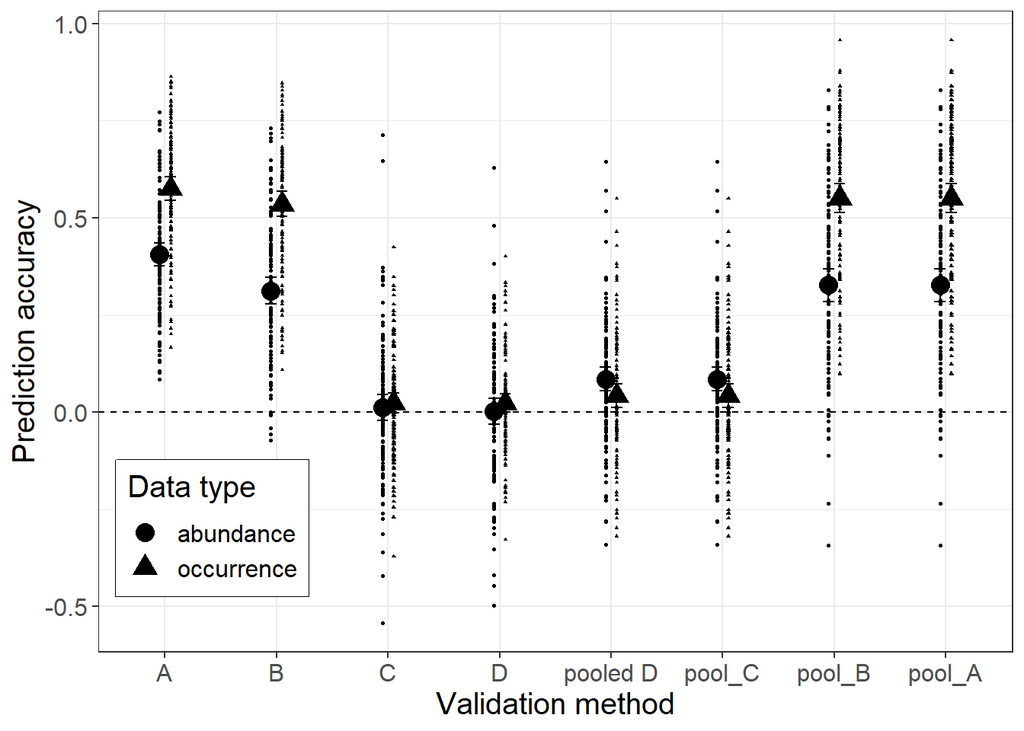

```r
ggsave("plot2_allmethods_alpha.png")
ggplot(stat, aes(y=accuracy, x=method,shape=Data_type)) +
  geom_errorbar(aes(ymin=accuracy-ci, ymax=accuracy+ci), colour="black", width=.2, position=pd) +
  ylab("Prediction accuracy") +
    xlab("Validation method") +
    theme_bw() +
    theme(legend.justification=c(1,1),
          legend.position=c(0.23,0.30),
          legend.box.background=element_rect())  +
    theme(text = element_text(size = 15)) +
    geom_point(position=pd, size=4) +
  scale_shape_discrete(name = "Data type", labels = c("abundance", "occurrence")) + geom_hline(yintercept = 0, linetype="dashed")+
  geom_point(data=res2,position=pd, size=0.5)
```

```r
ggsave("plot2_allmethods_noalpha.png")
```

### 3.3.5 Vanha kuvaaja

Vanha koodi on nyt toistaiseksi vielä tässä mutta alan kääntymään boxplottien puoleen.. Koodi ei toimi ilman muokkausta koska aineisto on nyt eri muodossa.

Ehkä jokin ylläolevista kuvaajista olisi hyvä.

```r
#piirretään sama kuvaaja, jossa nyt mukana myös poolatut arvot

#määritetään kuvalle raamit ja nimi
Line=c(-1,1)
Line2=c(-1,1)
Line3=c(0,0)

Line=cbind(Line,Line2)
Line=cbind(Line,Line3)

Line=as.data.frame(Line)

#pdf("Pooled_Fig1.pdf")

#määrittää 3x3 matriisin johon kuvat piirretään
layout(matrix(c(1,2,7,3,4,7,5,6,7), 3, 3, byrow = TRUE))

# a)
plot(pa_B~pa_A,data=res2,xlim=c(-1,1),
     ylim=c(-1,1),cex.axis=0.8,xlab="Prediction accuracy (A)",
     ylab="Prediction accuracy (B)")
lines(Line$Line,Line$Line2,lty="dashed")
lines(Line$Line,Line$Line3,col="grey",lty="dashed")
lines(Line$Line3,Line$Line,col="grey",lty="dashed")

text(-0.5,0.8,"a) Distribution",cex=0.8)


# b)
plot(abu_B~abu_A,data=res2,xlim=c(-1,1),
     ylim=c(-1,1),cex.axis=0.8,xlab="Prediction accuracy (A)",
     ylab="Prediction accuracy (B)")
lines(Line$Line,Line$Line2,lty="dashed")
lines(Line$Line,Line$Line3,col="grey",lty="dashed")
lines(Line$Line3,Line$Line,col="grey",lty="dashed")

text(-0.5,0.8,"b) Abundance",cex=0.8)

# c)
plot(pa_D~pa_C,data=res2,xlim=c(-1,1),
     ylim=c(-1,1),cex.axis=0.8,xlab="Prediction accuracy (C)",
     ylab="Prediction accuracy (D)")
lines(Line$Line,Line$Line2,lty="dashed")
lines(Line$Line,Line$Line3,col="grey",lty="dashed")
lines(Line$Line3,Line$Line,col="grey",lty="dashed")

text(-0.5,0.8,"c) Distribution, 2 km",cex=0.8)

# d)
plot(abu_D~abu_C,data=res2,xlim=c(-1,1),
     ylim=c(-1,1),cex.axis=0.8,xlab="Prediction accuracy (C)",
     ylab="Prediction accuracy (D)")
lines(Line$Line,Line$Line2,lty="dashed")
lines(Line$Line,Line$Line3,col="grey",lty="dashed")
lines(Line$Line3,Line$Line,col="grey",lty="dashed")

text(-0.5,0.8,"d) Abundance, 2 km",cex=0.8)

# e)
plot(pool_pa_change~pa_D,data=res2,xlim=c(-1,1),
     ylim=c(-1,1),cex.axis=0.8,xlab="Prediction accuracy (D)",
     ylab="Pooled prediction accuracy (change)")
lines(Line$Line,Line$Line2,lty="dashed")
lines(Line$Line,Line$Line3,col="grey",lty="dashed")
lines(Line$Line3,Line$Line,col="grey",lty="dashed")

text(-0.5,0.8,"e) Distribution, 50 km",cex=0.8)

# f)
plot(pool_abu_change~abu_D,data=res2,xlim=c(-1,1),
     ylim=c(-1,1),cex.axis=0.8,xlab="Prediction accuracy (D)",
     ylab="Pooled prediction accuracy (change)")
lines(Line$Line,Line$Line2,lty="dashed")
lines(Line$Line,Line$Line3,col="grey",lty="dashed")
lines(Line$Line3,Line$Line,col="grey",lty="dashed")

text(-0.5,0.8,"f) Abundance, 50km", cex=0.8)

#dev.off()
```